# CC02: Practical Exercises - Part I

Netherlands Institute for Health Sciences (NIHES), 2018-2019

## Exercise 0: Introduction to R

This exercise will introduce you to the basic options of R and Rstudio. We will use a data set of the growth of children after renal transplantation (GRRTX.SAV). We will explore this data using several procedures.

First we will learn you how to give basic commands in R:

1. Click on the File menu, choose ‘new file’, then ‘R script’.
2. Within the R script, enter the following sum: 5 + 8
3. To run this code set the cursor to the right of the 8 and press *ctrl* + *enter* or click on the ‘Run’ icon in the upper right corner of the script window. You can also enter commands directly into the *Console* window below the script. Within *Console* you only need to press *enter*. Both the script and console use the same variables and datasets, which all are visible within the environment window on the upper right side of the screen.

### a. Installing packages

*R* works with packages. Packages contain specific functions which extend the functionallity of the program. These packages should be downloaded once, when required. Before we can start, we need to download some packages.

Copy the code and run the script. `install.packages(c("car", "DescTools", "dplyr","epitools", "foreign", "ggplot2", "Hmisc", "kableExtra", "knitr", "mvtnorm", "openxlsx", "rio", "rms", "samplesizeCMH", "survival", "survminer"), dependencies = TRUE) # install all packages needed for the assignments and allow R to install the packages that are required for the packages (dependencies = TRUE)`

This will install all the package we need during the assignements for CC02. To actually use the package in Rstudio, type and run for example `library(rms)`. Installation has to be done just once, but the `library()` command has to be run each time you start working with a script, to load the external packages whose functions are used in that script.

#### Code

```r
library(rms) # load package
```

#### Output

After a successful install, you should get the message:  
`package 'rms' successfully unpacked and MD5 sums checked`

### b. Loading and inspecting a dataset

When you load a dataset, you should give it an appropriate (easy) name. There are several ways of loading a dataset in R. In order to load .SAV files, we use the function `read.spss()` from a package called *foreign*.  
Type for example: `mydata <- read.spss('namedataset.sav', to.data.frame = TRUE)`. The *to.data.frame* parameter of the `read.spss()` function influences how the function works. You do not need to understand what this parameter does at this moment. This code requires that the .sav file is saved in the same folder. In our case we can a folder with all the data files. By adding `./data` you tell `R` to go to the folder with the data. This gives us the following `R` code `mydata <- read.spss('./data/namedataset.sav', to.data.frame = TRUE)`.  
You can inspect the dataset by running `head(Grrtx)`, or by clicking on the name of the dataset in the top right window under ‘Environment’. How many cases does this dataset contain?

#### Hints

You can search for more information on `read.spss()` by typing `?read.spss`

#### Code

```r
library(foreign)  # load package

Grrtx <- read.spss('./data/GRRTX.SAV', to.data.frame = TRUE) # load dataset
```

#### Output

```r
Grrtx <- read.spss('./data/GRRTX.SAV', to.data.frame = TRUE)
```

#### Discussion

Variable lables can be seen by clicking on the name of the dataset in the top right ‘Environment’ window. When you type the `$` sign immediately behind the dataset, R tends to show the available variables autmatically.  
This dataset contains 52 cases (observations).

### c. Displaying descriptive statistics

When you open a new dataset, it is important to have a global overview of the data. The *rms* package we installed earlier is a useful tool to get a quick overview. Use the function `describe()` to find oud the mean, median and highest age, and the percentage of men.  
R has standard functions which are suitable for data inspection as well. Try `str()` and `summary()` for example, these functions do not require additional packages. Examine what these functions return on the screen.

#### Hints

You can search for more information on `describe()` by typing `?describe`

#### Code

```r
# load packages
library(foreign)
library(rms)

# load dataset
Grrtx <- read.spss('./data/GRRTX.SAV', to.data.frame = TRUE)

# use the function describe()
describe(Grrtx$AGETX)
describe(Grrtx$SEX)
```

#### Output

```r
describe(Grrtx$AGETX)
```

```
## Grrtx$AGETX
##        n  missing distinct     Info     Mean      Gmd      .05      .10
##       52        0       52        1    11.43    3.022    7.074    7.644
##      .25      .50      .75      .90      .95
##    9.183   11.689   13.830   14.503   14.727
##
## lowest :  5.021218  6.401095  6.948665  7.175907  7.477070
## highest: 14.510609 14.529774 14.967830 15.096509 15.515400
```

```r
describe(Grrtx$SEX)
```

```
## Grrtx$SEX
##        n  missing distinct
##       52        0        2
##
## Value          M     F
## Frequency     31    21
## Proportion 0.596 0.404
```

#### Discussion

`describe()` gives a lot of useful information in one go. Standard R has many additional usefull functions for the various descriptive statistics, e.g. `mean()`, `median()` and `max()`

### d. Creating basic tables and graphs

For basic tables, R has a function called `table()`. You can find percentages of table rows and collumns for a table by using `prop.table()`.  
Using these functions to discover how many boys had urinary tract abnormalities as diagnosis. What percentage of all boys is that?  
Basic R also has convenient functions to create plots. More advanced plots can be created with the packages *ggplot2* or *lattice*, but for now the basic functions suffice:

1. Create a histogram of age with the function `hist()`
2. Use the function `boxplot()` to create a boxplot of final height stratified by sex.
3. Use the function `plot()` to create a scatterplot of final height by target height

#### Hints

1. `prop.table()` shows cell percentages. With `1` as the second argument, it shows row percentages, and with `2` it returns column percentages. For example: prop.table(my_table, 2)
2. create a table with the function `table()`, and store that as `Table.1` in order to it later in `prop.table()`.
3. The first argument for the function `boxplot` has the structure `y~grouping variable`.
4. In all basic plotting functions, the argument `main` can be used to set a title, and `xlab` and `ylab` can be used to set axis labels.

#### Code

```r
Grrtx <- read.spss('./data/GRRTX.SAV', to.data.frame = TRUE) # load dataset

table(Grrtx$SEX, Grrtx$TXNUM) # create the table

# show row percentages
Table.1 <- table(Grrtx$SEX, Grrtx$DIAGN)
prop.table(Table.1, 1)

# create a histogram of age
hist(Grrtx$AGETX, main = "Age at transplant", xlab = "Age", col = "green")

# create a boxplot
boxplot(Grrtx$FINALHT ~ Grrtx$SEX, main = "Final Height", ylab = "Height (cm)", names = c("Boys", "Girls"), col = c("cyan", "magenta"))

# create a scatterplot
plot(Grrtx$TARHT, Grrtx$FINALHT, main = "Target height vs. final height", xlab = "Target height (cm)", ylab = "Final height (cm)", col = "green4", cex = 2, lwd = 2)
```

#### Output

```r
# create the table
table(Grrtx$SEX, Grrtx$TXNUM)
```

```
##
##      1  2  3
##   M 24  6  1
##   F 17  2  2
```

```r
# show row percentages
Table.1 <- table(Grrtx$SEX, Grrtx$DIAGN)
prop.table(Table.1, 1)
```

```
##
##     urinary tract abnormalities glomerulpathies nephrotic syndrome
##   M                   0.4193548       0.5806452          0.0000000
##   F                   0.2380952       0.7619048          0.0000000
```

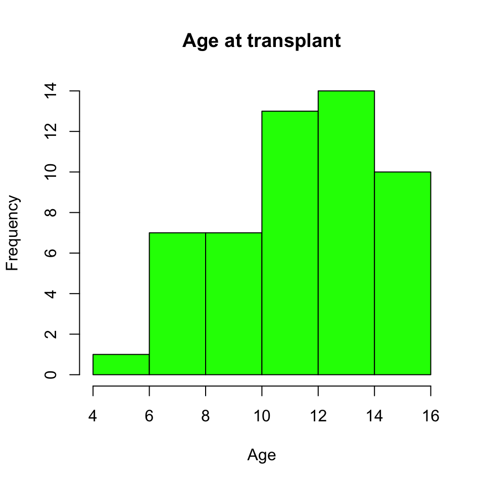

```r
# create a histogram of age
hist(Grrtx$AGETX, main = "Age at transplant", xlab = "Age", col = "green")
```

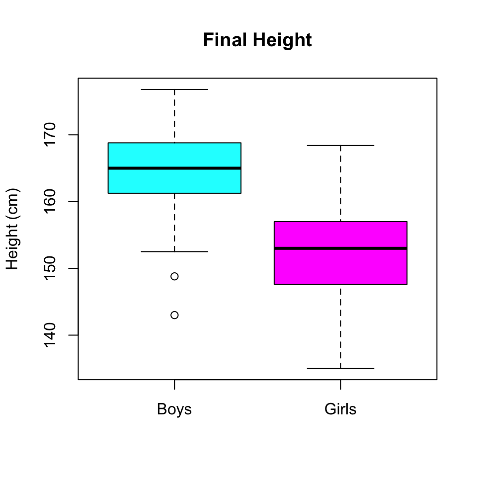

```r
# create a boxplot
boxplot(Grrtx$FINALHT~Grrtx$SEX, main = "Final Height", ylab = "Height (cm)", names = c("Boys", "Girls"), col = c("cyan", "magenta"))
```

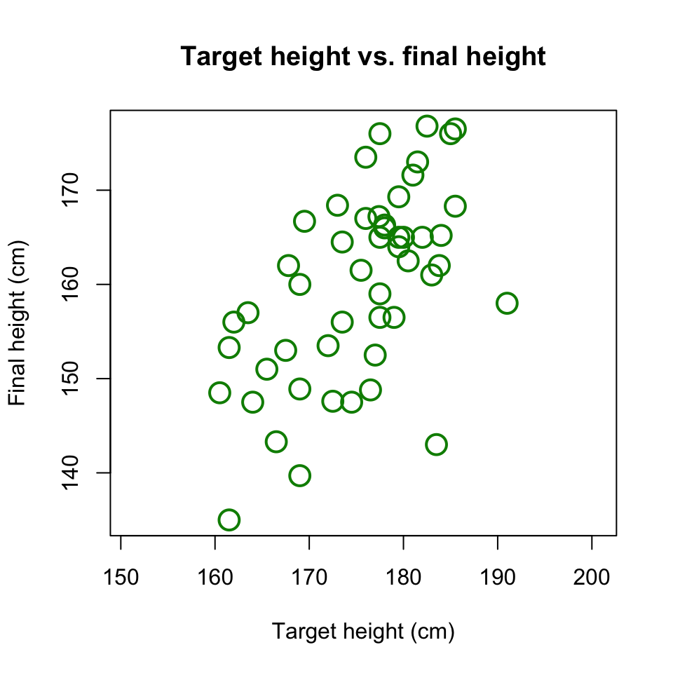

```r
# create a scatterplot
plot(Grrtx$TARHT, Grrtx$FINALHT, main = "Target height vs. final height", xlab = "Target height (cm)", ylab = "Final height (cm)", col = "green4", cex = 2, lwd = 2, asp = 1)
```

### e. Computing new variables

We will now create a new variable with the name Difhtsds. This variable is the difference between HTSDSTX and HTSDSHD.

1. Type: `Grrtx$Difhtsds <- Grrtx$HTSDSTX - Grrtx$HTSDSHD`
2. What is the mean of the new variable?
3. Produce a histogram of the new variable.
4. Create a new variable `Lndurhd` wich is the natural logarithm of `DURHD`.

It is also possible to do a transformation for only a subgroup of cases:

1. Type: `Grrtx$Finalsds[Grrtx$SEX =="M"] <- (Grrtx$FINALHT[Grrtx$SEX =="M"] - 182.0)/6.7`
2. In the same way compute `Grrtx$Finalsds` for women with the formula: (FINALHT - 168.3)/6.2
3. Compare the means of FINALHT and Finalsds for both sexes.

#### Hints

1. The natural logarithm is created with the function `log()`: without a second argument, the base of `log()` is *e*.
2. You can run `mean()` per subgroup using `tapply()`. See `?tapply` for help.

#### Code

```r
Grrtx <- read.spss('./data/GRRTX.SAV', to.data.frame = TRUE) # load dataset

Grrtx$Difhtsds <- Grrtx$HTSDSTX - Grrtx$HTSDSHD # create new variable Difhtsds

mean(Grrtx$Difhtsds) # calculate the mean

# create a histogram
hist(Grrtx$Difhtsds, main = "Difference in SDS", xlab = "Difference in SDS", col = "orange")
Grrtx$Lndurhd <- log(Grrtx$DURHD) # create Lndurhd

# calculate Finalsds for men and women separately
Grrtx$Finalsds[Grrtx$SEX =="M"] <- (Grrtx$FINALHT[Grrtx$SEX =="M"] - 182.0) / 6.7
Grrtx$Finalsds[Grrtx$SEX =="F"] <- (Grrtx$FINALHT[Grrtx$SEX =="F"] - 168.3) / 6.2

# compare the means
tapply(Grrtx$FINALHT, Grrtx$SEX, mean)
tapply(Grrtx$Finalsds, Grrtx$SEX, mean)
```

#### Output

```r
Grrtx$Difhtsds <- Grrtx$HTSDSTX - Grrtx$HTSDSHD # create new variable Difhtsds
mean(Grrtx$Difhtsds)  # calculate the mean
```

```
## [1] -0.4282516
```

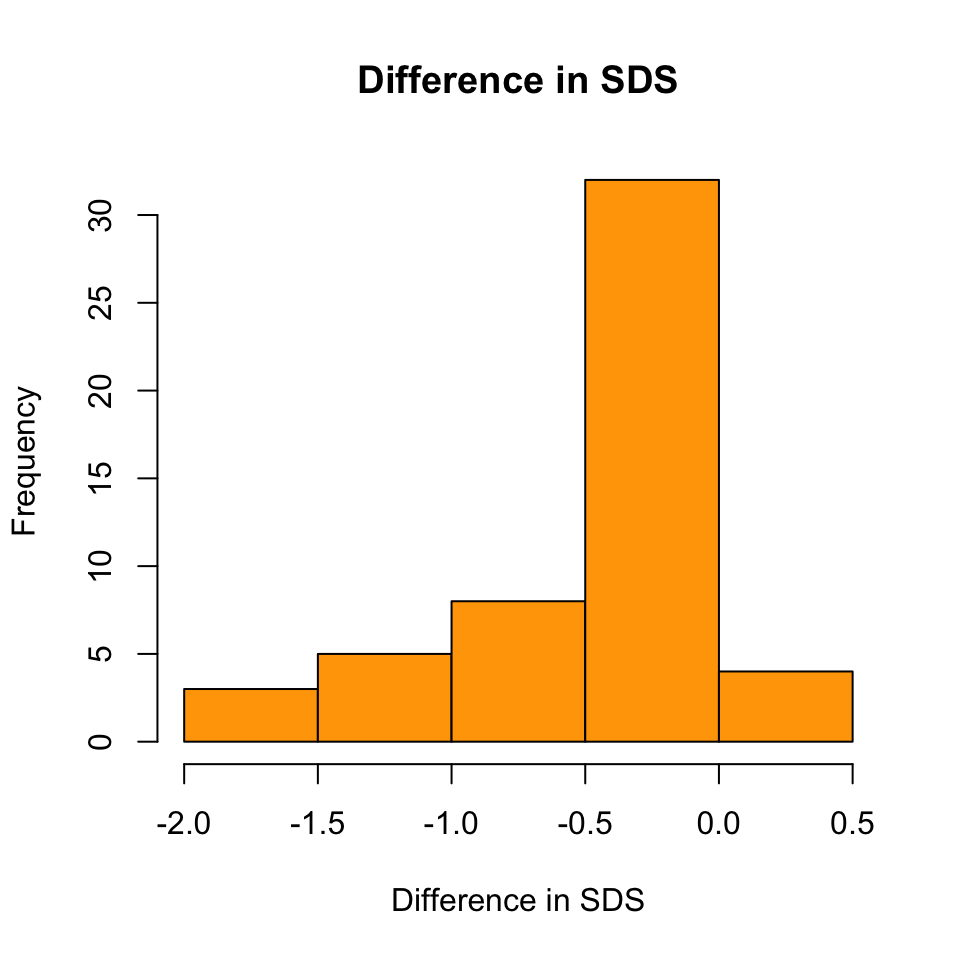

```r
# create a histogram
hist(Grrtx$Difhtsds, main = "Difference in SDS", xlab = "Difference in SDS", col = "orange")
```

```r
# create Lndurhd
Grrtx$Lndurhd <- log(Grrtx$DURHD)

# calculate Finalsds for men and women separately
Grrtx$Finalsds[Grrtx$SEX =="M"] <- (Grrtx$FINALHT[Grrtx$SEX =="M"] - 182.0) / 6.7
Grrtx$Finalsds[Grrtx$SEX =="F"] <- (Grrtx$FINALHT[Grrtx$SEX =="F"] - 168.3) / 6.2

# compare the means
tapply(Grrtx$FINALHT, Grrtx$SEX, mean)
```

```
##        M        F
## 164.6806 152.8524
```

```r
tapply(Grrtx$Finalsds, Grrtx$SEX, mean)
```

```
##         M         F
## -2.584978 -2.491551
```

#### Discussion

`tapply()` applies a function to each category of a variable.

### f. Recoding variables

Sometimes we want to recode a continuous variable into a categorical, or change the categories of a categorical variable. In R, the the procedure is the same for both cases.  
We will give two examples:  
The variable `TXNUM`, the number of transplantations, has the values 1, 2 and 3. Now we create a new variable, indicating ‘More than 1 transplantation’, i.e. 0 = no, 1 = yes:

1. `Grrtx$More1tx[Grrtx$TXNUM == 1] <- 0`
2. `Grrtx$More1tx[Grrtx$TXNUM == 2] <- 1`
3. `Grrtx$More1tx[Grrtx$TXNUM == 3] <- 1`

Run the code, and show how many patients had more than one transplantation.  
The variable `AGETX`, age at first transplantation, ranges from 5 to 15.5. Now we want to categorize age into different groups: lower than 8, between 8 and 12, and older than 12:

1. `Grrtx$Agegr[Grrtx$AGETX < 8] <- 1`
2. `Grrtx$Agegr[Grrtx$AGETX > 8 & Grrtx$AGETX < 12] <- 2`
3. `Grrtx$Agegr[Grrtx$AGETX > 12] <- 3`

Run the code and create an bar plot of this new variable.

#### Hints

The square brackets `[]` behind a variable name can be used to specify which subset of the variable is used: [rows,columns].  
A bar chart can be made with `barplot()`. It uses as input the counts per category, which you can create with `table()`.

```r
counts <- table(Grrtx$Agegr)
```

#### Code

```r
# load dataset
Grrtx <- read.spss('./data/GRRTX.SAV', to.data.frame = TRUE)

# create new variable More1tx
Grrtx$More1tx[Grrtx$TXNUM == 1] <- 0
Grrtx$More1tx[Grrtx$TXNUM == 2] <- 1
Grrtx$More1tx[Grrtx$TXNUM == 3] <- 1

# Show how many patients had more than one translpant
table(Grrtx$More1tx)

# create new variable Agegr
Grrtx$Agegr[Grrtx$AGETX < 8] <- 1
Grrtx$Agegr[Grrtx$AGETX > 8 & Grrtx$AGETX < 12] <- 2
Grrtx$Agegr[Grrtx$AGETX > 12] <- 3

# show barplot of Agegr
counts <- table(Grrtx$Agegr)
barplot(counts, ylab = "Count", xlab = "Age categories", main = "Patients per age category", col = c("green", "orange", "red"))
```

#### Output

```r
# create new variable More1tx
Grrtx$More1tx[Grrtx$TXNUM == 1] <- 0
Grrtx$More1tx[Grrtx$TXNUM == 2] <- 1
Grrtx$More1tx[Grrtx$TXNUM == 3] <- 1

# Show how many patients had more than one translpant
table(Grrtx$More1tx)
```

```
##
##  0  1
## 41 11
```

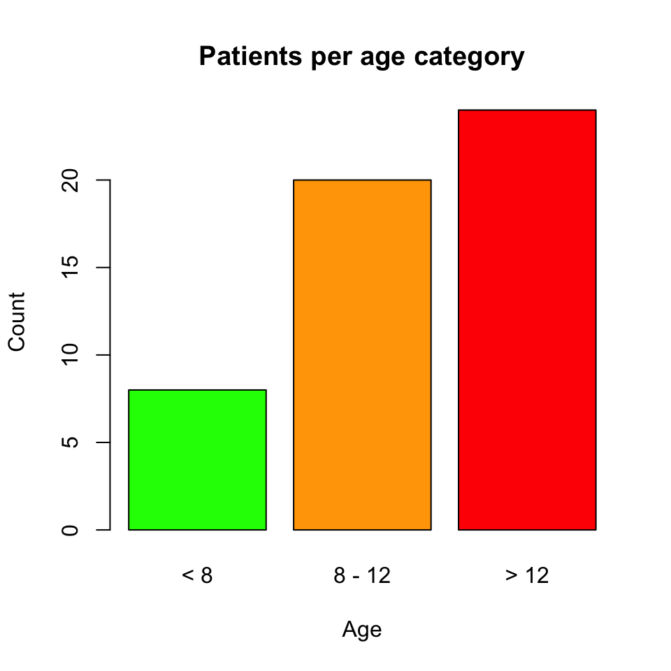

```r
# create new variable Agegr
Grrtx$Agegr[Grrtx$AGETX < 8] <- 1
Grrtx$Agegr[Grrtx$AGETX > 8 & Grrtx$AGETX < 12] <- 2
Grrtx$Agegr[Grrtx$AGETX > 12] <- 3

# show histogram of Agegr
counts <- table(Grrtx$Agegr)
barplot(counts, ylab = "Count", xlab = "Age", main = "Patients per age category", col = c("green","orange", "red"), names.arg = c("< 8", "8 - 12", "> 12"))
```

## Exercise 1: Descriptive statistics

In this exercise we are going to explore the data set BLDPRES using R. This data set contains several characteristics (including age, sex, systolic and diastolic blood pressure, etc.) of 328 individuals from a rural area in Pakistan.

### Question a

Start the R program. Open the dataset. Inspect the dataset using the buttons on the toolbar and by using the methods described in Exercise 0. Which variables are numerical and which are categorical?

#### Hints

To get a quick overview of a dataset, you can also use the function `summary()`. To find the class of an individual varaible you can use `class()`.

#### Code

```r
summary(Bldpres)   # overall summary
class(Bldpres$ses) # class of ses
```

#### Output

```r
summary(Bldpres)   # overall summary
```

```
##       age             sys             dias            weight
##  Min.   :20.00   Min.   : 85.0   Min.   : 57.50   Min.   : 27.00
##  1st Qu.:26.00   1st Qu.:115.0   1st Qu.: 75.00   1st Qu.: 43.00
##  Median :35.00   Median :122.5   Median : 80.00   Median : 49.00
##  Mean   :39.12   Mean   :125.2   Mean   : 81.12   Mean   : 51.28
##  3rd Qu.:50.00   3rd Qu.:132.5   3rd Qu.: 87.50   3rd Qu.: 58.00
##  Max.   :81.00   Max.   :195.0   Max.   :110.00   Max.   :102.00
##      pulse            sex                 ses          RES_1
##  Min.   : 40.00   male  :145   lower class  :138   Min.   :-50.446
##  1st Qu.: 72.00   female:183    middle class:127   1st Qu.:-10.375
##  Median : 84.00                upperclass   : 63   Median : -1.053
##  Mean   : 82.15                                    Mean   :  0.000
##  3rd Qu.: 88.00                                    3rd Qu.:  8.486
##  Max.   :120.00                                    Max.   : 55.581
##      res_2
##  Min.   :   0.00
##  1st Qu.:  22.10
##  Median :  94.46
##  Mean   : 265.11
##  3rd Qu.: 290.88
##  Max.   :3089.28
```

```r
class(Bldpres$ses) # class of ses
```

```
## [1] "factor"
```

#### Discussion

The variables `age`, `sys`, `dias`, `weight`, `pulse`, `RES_1`, and `RES_2` are continuous, while `sex` and `ses` are categorical. In R, a categorical variable is called a factor.

### Question b

We will use the `describe()` function and create basic graphs and histograms to produce a concise overview of the variables. We start with the variable `ses`. How many missing observations does this variable contain?

#### Hints

The `describe()` function is from the package *rms*.  
Alternative options from the standard R package are: `summary(dataset)` and `table(is.na(dataset$variable))`. The first option shows the number of missing observations for each variable in a dataset. The second option returns a table with the number of missing observations for a specific variable.

#### Code

```r
library(rms) # load library
Bldpres <- read.spss('./data/BLDPRES.SAV', to.data.frame = TRUE) # load dataset
describe(Bldpres$ses) # use describe
```

#### Output

```r
describe(Bldpres$ses)
```

```
## Bldpres$ses
##        n  missing distinct
##      328        0        3
##
## Value       lower class middle class   upperclass
## Frequency           138          127           63
## Proportion        0.421        0.387        0.192
```

#### Discussion

There are no missing values for `ses` in this dataset.

### Question c

Make a frequency table of `age`. What are the smallest (i.e. minimum) and largest (e.a. maximum) values of age? What is the age range? What is the median value? What are the values of the 25th and the 75th percentile? What is the interquartile range? Create a histogram for age. Is the distribution symmetric or skewed?

#### Hints

Again consider the `summary()` function. Alternative options are individual commands for each descriptive. For example `min()` or `range()` or `quantile()`.

#### Code

```r
describe(Bldpres$age) # use describe()

# alternative examples
min(Bldpres$age)
quantile(Bldpres$age)

hist(Bldpres$age) # create a histogram
```

#### Output

```r
describe(Bldpres$age)
```

```
## Bldpres$age
##        n  missing distinct     Info     Mean      Gmd      .05      .10
##      328        0       55    0.999    39.12    16.89    21.00    22.00
##      .25      .50      .75      .90      .95
##    26.00    35.00    50.00    63.00    65.65
##
## lowest : 20 21 22 23 24, highest: 75 76 78 80 81
```

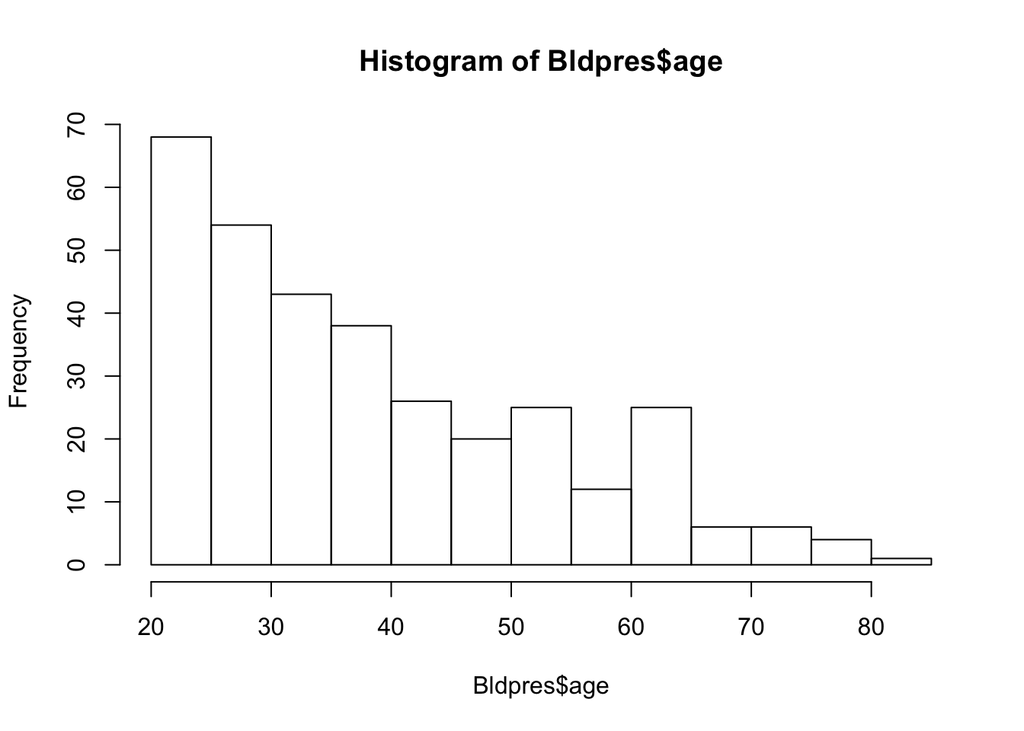

```r
hist(Bldpres$age)
```

#### Discussion

Please inspect the output of the descriptive functions and control your answers by inspecting the plot!

### Question d

Now we are making some plots:

1. Make a simple barchart for the counts of the variable `sex`.
2. Make a barchart for the variable `sex` where the bars represent the mean age of men and women.
3. Make a histogram for the systolic blood pressure.
4. Make a box plot for systolic blood pressure divided into the three social economic status groups.

#### Hints

1. A bar chart can be made with `barplot()`.
2. To calculate the counts per category, use `table()`.
3. To calculate the mean age per cagegory, use `tapply()`: `tapply(variable, category, mean)`
4. To create a box plot by category, use `boxplot()` like this: `boxplot(variable~category)`

#### Code

```r
Bldpres <- read.spss('./data/BLDPRES.SAV', to.data.frame = TRUE) # load dataset

# create barchart of sex with counts
counts <- table(Bldpres$sex)
barplot(counts, ylab = "Count", xlab = "Sex", main = "Men and women", col = c("cyan", "magenta"), names.arg = c("Men", "Women"))

# create barchart of sex with mean age
agemeans <- tapply(Bldpres$age , Bldpres$sex, mean)
barplot(agemeans, ylab = "Mean age", xlab = "Sex", main = "Men and women", col = c("cyan", "magenta"), names.arg = c("Men", "Women"))

# create histogram of systolic blood pressure
hist(Bldpres$sys, col = "green", xlab = "Systolic blood pressure", main = "Histogram of systolic blood pressure")

# create box plot for systolic blood pressure by ses.
boxplot(Bldpres$sys~Bldpres$ses, names = c("Lower", "Middle", "Upper"), main = "Boxplot of sys by ses", ylab = "Systolic blood pressure", xlab = "Social-economic status", col = c("green", "orange", "red"))
```

#### Output

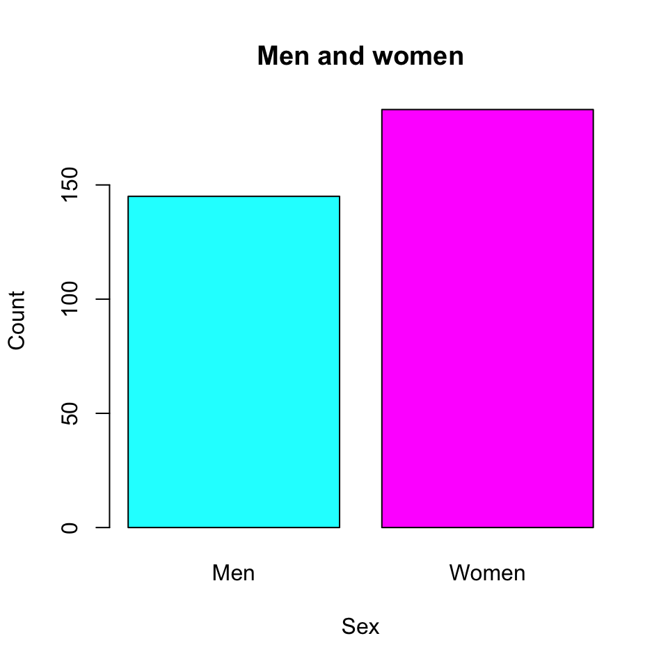

```r
# create barchart of sex with counts
counts <- table(Bldpres$sex)
barplot(counts, ylab = "Count", xlab = "Sex", main = "Men and women", col = c("cyan", "magenta"), names.arg = c("Men", "Women"))
```

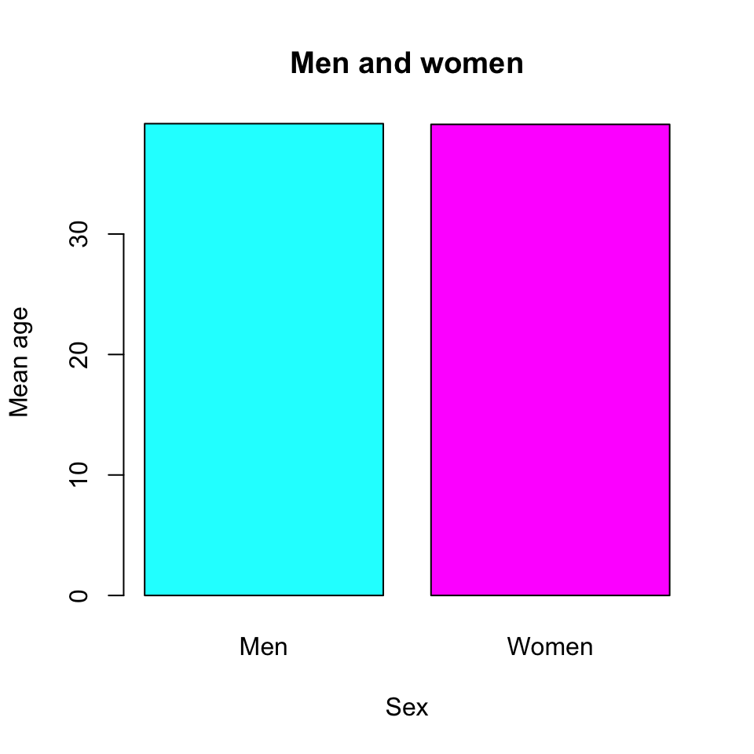

```r
# create barchart of sex with mean age
agemeans <- tapply(Bldpres$age , Bldpres$sex, mean)
barplot(agemeans, ylab = "Mean age", xlab = "Sex", main = "Men and women", col = c("cyan", "magenta"), names.arg = c("Men", "Women"))
```

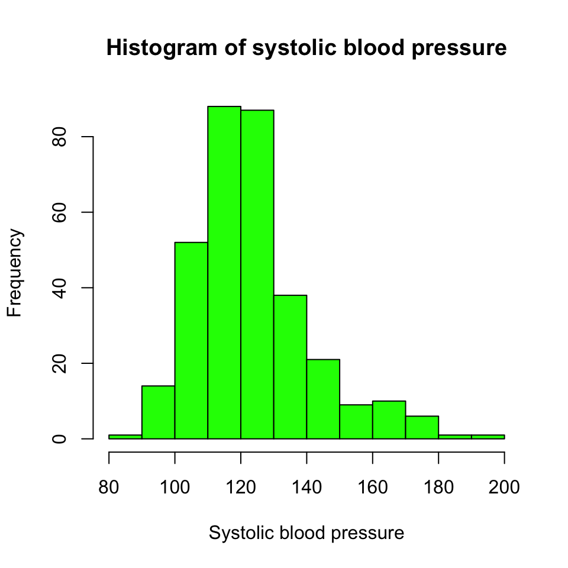

```r
# create histogram of systolic blood pressure
hist(Bldpres$sys, col = "green", xlab = "Systolic blood pressure", main = "Histogram of systolic blood pressure")
```

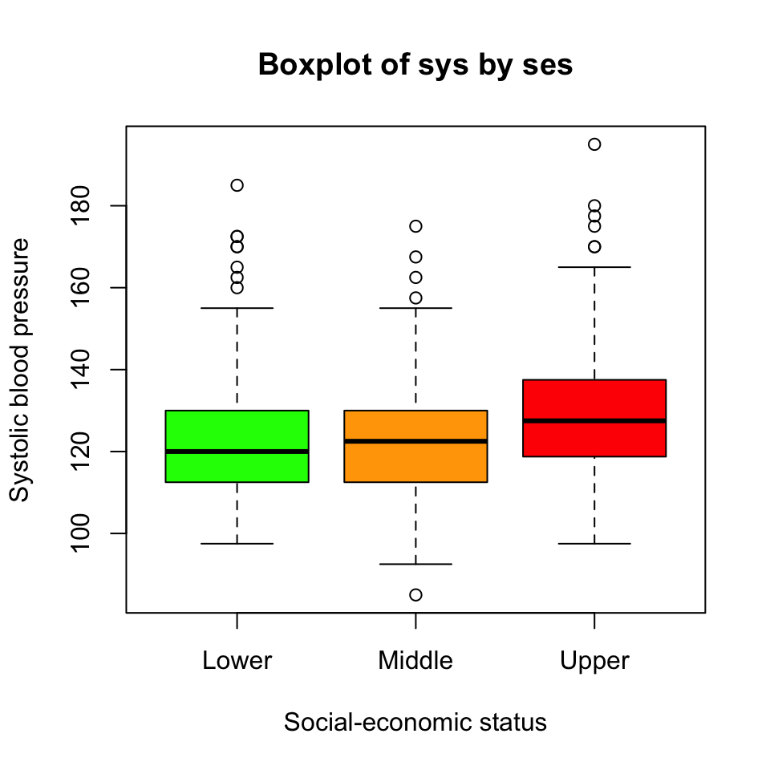

```r
# create box plot for systolic blood pressure by ses.
boxplot(Bldpres$sys ~ Bldpres$ses, names = c("Lower", "Middle", "Upper"), main = "Boxplot of sys by ses", ylab = "Systolic blood pressure", xlab = "Social-economic status", col = c("green", "orange", "red"))
```

#### Discussion

No discussion (yet)

## Exercise 3: Confidence intervals for means

The data in the accompanying table are a sample of cholesterol levels taken from 24 hospital employees who were on a standard American diet and who agreed to adopt a vegetarian diet for 1 month. Serum-cholesterol measurements were made before adopting the diet and 1 month after. Use R only for part b. If you don’t have a calculator, you can use R as a calculator as well.

| Subject | before | after | before-after |
| --- | --- | --- | --- |
| 1 | 195 | 146 | 49 |
| 2 | 145 | 155 | -10 |
| 3 | 205 | 178 | 27 |
| 4 | 159 | 146 | 13 |
| 5 | 244 | 208 | 36 |
| 6 | 166 | 147 | 19 |
| 7 | 250 | 202 | 48 |
| 8 | 236 | 215 | 21 |
| 9 | 192 | 184 | 8 |
| 10 | 224 | 208 | 16 |
| 11 | 238 | 206 | 32 |
| 12 | 197 | 169 | 28 |
| 13 | 169 | 182 | -13 |
| 14 | 158 | 127 | 31 |
| 15 | 151 | 149 | 2 |
| 16 | 197 | 178 | 19 |
| 17 | 180 | 161 | 19 |
| 18 | 222 | 187 | 35 |
| 19 | 168 | 176 | -8 |
| 20 | 168 | 145 | 23 |
| 21 | 167 | 154 | 13 |
| 22 | 161 | 153 | 8 |
| 23 | 178 | 137 | 41 |
| 24 | 137 | 125 | 12 |
| Mean | 188 | 168 | 20 |
| SD | 33 | 27 | 17 |

### Question a

Do the following things manually:

1. Compute the approximate 95% confidence intervals for the mean cholesterol levels before and after the diet.
2. Compute the approximate 95%, and 90% confidence intervals for the mean difference in serum-cholesterol level before and after the diet.
3. Assuming that the differences (before - after) come from a normal distribution, give the **exact** 95% confidence interval for the mean difference, based on the t-distribution.

### Question b

The SPSS system file DIET.SAV contains the data of this exercise. Open the data set and inspect the data. Make a new variable containing the difference before - after.  
Then calculate the 95% CI for the mean of this veriable, and verify that this is the same as computed in question a.

#### Hints

Use the `mean()` and `sd()` functions to calculate the mean and standard deviation.

#### Code

```r
library(foreitn) # load library

Diet <- read.spss('./data/DIET.SAV', to.data.frame = TRUE) # load dataset
Diet$diff <- Diet$BEFORE - Diet$AFTER # create new variable

# calculate 95% CI of the mean
n <- length(Diet$diff)  #number of participants
mean <- mean(Diet$diff)
sd <- sd(Diet$diff)
se <- (1.96 * sd) / sqrt(n)
lower.limit <- mean - se
upper.limit <- mean + se
lower.limit
upper.limit
```

#### Output

```r
Diet$diff <- Diet$BEFORE - Diet$AFTER # create new variable

# calculate 95% CI of the mean
n <- length(Diet$diff)   # number of participants
mean <- mean(Diet$diff)
sd <- sd(Diet$diff)
se <- (1.96*sd)  /sqrt(n)
lower.limit <- mean - se
upper.limit <- mean + se
lower.limit
```

```
## [1] 12.81797
```

```r
upper.limit
```

```
## [1] 26.26536
```

#### Discussion

You could calculate the standard error and lower and upper bound of the confidence interval with the results from the `mean()` and `sd()` function as demonstrated in the code example.  
An even quicker way than the example code is the function `ci.mean()` from the package *Publish*

## Exercise 4: Test for mean

Again we use the dataset BLDPRES.SAV.

### Question a

Suppose we are interested in the mean of diastolic blood pressure. What is the estimated mean for this rural area in Pakistan? Assume that you know that in your own country the mean diastolic blood pressure is exactly 79.5 mmHg. Is it justified to claim that in this Pakistan area the diastolic blood pressure is higher? To answer this question, perform the one sample t-test to test the null hypothesis that the population mean is 79.5. In R this can be done by performing a t-test with the function `t.test()`, setting the mu to 79.5.

#### Hints

The function `t.test()` needs two arguments: the variable and the mean for comparison. You can find all the arguments of `t.test()` using `?`

```r
?t.test
```

#### Code

```r
# load library
library(foreign)

# load dataset
Bldpres <- read.spss('data/BLDPRES.SAV', to.data.frame = TRUE)

# perform t-test
t.test(Bldpres$dias, mu = 79.5)
```

#### Output

```r
t.test(Bldpres$dias, mu = 79.5)
```

```
##
##  One Sample t-test
##
## data:  Bldpres$dias
## t = 2.8883, df = 327, p-value = 0.004132
## alternative hypothesis: true mean is not equal to 79.5
## 95 percent confidence interval:
##  80.01819 82.23181
## sample estimates:
## mean of x
##    81.125
```

#### Discussion

The output shows that the 95% confidence interval of diastolic blood pressure is between 80 and 82 mmHg. The value of 79.5 mmHg lies outside (below) this interval.

## Exercise 5: Comparison of two means

Two means can be compared using the Student’s two-sample t-test. This test is carried out in R by the function `t.test()`. The default level of confidence for confidence intervals is 95%, but you can change that setting with the `conf.level` parameter. For this exercise we again use the data set BLDPRES.

### Question a

To investigate the difference in body weight between men and women, carry out a t-test. Is it justified to use the standard t-test which assumes equal standard deviations? What is the P-value and what is your conclusion? What is the 95% confidence interval for the difference in body weight? What is the 99% confidence interval?

#### Hints

To test if the standard deviations are different in men and women, use the `leveneTest()` function from the ‘car’ library. You can read instructions in how to use `leveneTest()` and `t.test()` by typing `?` in front of it. To test the difference in weight in `t.test()`, you can specify the formula with a `~` between the variables.

```r
?t.test
```

#### Code

```r
# load libraries
library(foreign)
library(car)

# load dataset
Bldpres <- read.spss('data/BLDPRES.SAV', to.data.frame = TRUE)

# Levene's test
leveneTest(Bldpres$weight ~ Bldpres$sex)

# compare the mean weight between men and women
t.test(Bldpres$weight~Bldpres$sex)

# set the confidence interval to 99%
t.test(Bldpres$weight~Bldpres$sex, conf.level = 0.99)
```

#### Output

```r
leveneTest(Bldpres$weight, Bldpres$sex)
```

```
## Levene's Test for Homogeneity of Variance (center = median)
##        Df F value Pr(>F)
## group   1  2.4054 0.1219
##       326
```

```r
t.test(Bldpres$weight~Bldpres$sex)
```

```
##
##  Welch Two Sample t-test
##
## data:  Bldpres$weight by Bldpres$sex
## t = 7.0588, df = 280.12, p-value = 1.324e-11
## alternative hypothesis: true difference in means is not equal to 0
## 95 percent confidence interval:
##   6.228823 11.046247
## sample estimates:
##   mean in group male mean in group female
##             56.09655             47.45902
```

```r
t.test(Bldpres$weight~Bldpres$sex, conf.level = 0.99)
```

```
##
##  Welch Two Sample t-test
##
## data:  Bldpres$weight by Bldpres$sex
## t = 7.0588, df = 280.12, p-value = 1.324e-11
## alternative hypothesis: true difference in means is not equal to 0
## 99 percent confidence interval:
##   5.464013 11.811058
## sample estimates:
##   mean in group male mean in group female
##             56.09655             47.45902
```

#### Discussion

Levene’s test has a p-value of 0.12, so we can assume the standard deviation of weight is the same in men and in women. The p-value of the t-test is 1.32 x 10<sup>-11</sup>, so the difference in weight is significant. Notice that the 99% confidence interval is wider than the 95% confidence interval.

### Question b

Make a new variable, for instance called *Highbp*, that is equal to 1 if dias is larger than 90, and equal to 0 otherwise. Test the differences between these two groups for systolic blood pressure, body weight and pulse frequency. What is your conclusion?

#### Hints

The recoding of dias can be accomplished in various ways. A very quick way is the `ifelse` function, but it can also be done manually. For the Levene’s test, you need to set Highbp as a factor with `as.factor()`.

#### Code

```r
# load libraries
library(foreign)
library(car)

# load dataset
Bldpres <- read.spss('data/BLDPRES.SAV', to.data.frame=TRUE)

# use ifelse() to create Highbp
Bldpres$Highbp <- ifelse(Bldpres$dias > 90, 1, 0)

# alternative manual way to create Highbp
Bldpres$Highbp[Bldpres$dias > 90] <- 1
Bldpres$Highbp[Bldpres$dias <= 90] <- 0

# set Highbp as a factor
Bldpres$Highbp <- as.factor(Bldpres$Highbp)

# Testing against Systolic blood pressure, body weight and pulse frequency
# Levene's tests
leveneTest(Bldpres$sys ~ Bldpres$Highbp)
leveneTest(Bldpres$weight ~ Bldpres$Highbp)
leveneTest(Bldpres$pulse ~ Bldpres$Highbp)

# t-tests
t.test(Bldpres$sys ~ Bldpres$Highbp)
t.test(Bldpres$weight ~ Bldpres$Highbp, var.equal = FALSE)
t.test(Bldpres$pulse ~ Bldpres$Highbp, var.equal = FALSE)
```

#### Output

```r
Bldpres$Highbp <- ifelse(Bldpres$dias > 90, 1, 0)
Bldpres$Highbp <- as.factor(Bldpres$Highbp)
leveneTest(Bldpres$sys ~ Bldpres$Highbp)
```

```
## Levene's Test for Homogeneity of Variance (center = median)
##        Df F value  Pr(>F)
## group   1  4.1092 0.04346 *
##       326
## ---
## Signif. codes:  0 '***' 0.001 '**' 0.01 '*' 0.05 '.' 0.1 ' ' 1
```

```r
leveneTest(Bldpres$weight ~ Bldpres$Highbp)
```

```
## Levene's Test for Homogeneity of Variance (center = median)
##        Df F value  Pr(>F)
## group   1    4.64 0.03197 *
##       326
## ---
## Signif. codes:  0 '***' 0.001 '**' 0.01 '*' 0.05 '.' 0.1 ' ' 1
```

```r
leveneTest(Bldpres$pulse ~ Bldpres$Highbp)
```

```
## Levene's Test for Homogeneity of Variance (center = median)
##        Df F value Pr(>F)
## group   1  0.0128 0.9101
##       326
```

```r
t.test(Bldpres$sys ~ Bldpres$Highbp)
```

```
##
##  Welch Two Sample t-test
##
## data:  Bldpres$sys by Bldpres$Highbp
## t = -9.9169, df = 54.905, p-value = 7.661e-14
## alternative hypothesis: true difference in means is not equal to 0
## 95 percent confidence interval:
##  -32.44035 -21.53282
## sample estimates:
## mean in group 0 mean in group 1
##        121.3830        148.3696
```

```r
t.test(Bldpres$weight ~ Bldpres$Highbp)
```

```
##
##  Welch Two Sample t-test
##
## data:  Bldpres$weight by Bldpres$Highbp
## t = -3.344, df = 53.754, p-value = 0.00151
## alternative hypothesis: true difference in means is not equal to 0
## 95 percent confidence interval:
##  -11.739043  -2.938416
## sample estimates:
## mean in group 0 mean in group 1
##        50.24823        57.58696
```

```r
t.test(Bldpres$pulse ~ Bldpres$Highbp)
```

```
##
##  Welch Two Sample t-test
##
## data:  Bldpres$pulse by Bldpres$Highbp
## t = -2.7182, df = 60.479, p-value = 0.008551
## alternative hypothesis: true difference in means is not equal to 0
## 95 percent confidence interval:
##  -8.739547 -1.330450
## sample estimates:
## mean in group 0 mean in group 1
##        81.44326        86.47826
```

#### Discussion

For systolic blood pressure and body weight, Levene’s test is significant. Therefore, it is necessary to use the `var.equal = FALSE` parameter. Due to the value of this parameter, the pooled variance is not used, but an approximation to the degrees of freedom. In any case, the Highbp groups differ significantly in systolic blood pressure, body weight and pulse frequency.

## Exercise 6: Paired continuous data

The data below are from Charles Darwin’s study of cross- and self-fertilization (Darwin C., 1876: “The effect of cross- and self-fertilization in the vegetable kingdom”). Pairs of seedlings of the same age, one produced by cross-fertilization and the other by self-fertilization, were grown together so that the members of each pair were reared under nearly identical conditions. The aim was to demonstrate the greater vigour of the cross-fertilized plants. The data are the final heights of each plant after a fixed period of time. The dataset is called DARWIN.SAV (see page A9 in the Appendix).

| Pair | Cross-fertilized | Self-fertilized |
| --- | --- | --- |
| 1 | 23.5 | 17.4 |
| 2 | 12.0 | 20.4 |
| 3 | 21.0 | 20.0 |
| 4 | 22.0 | 20.0 |
| 5 | 19.1 | 18.4 |
| 6 | 21.5 | 18.6 |
| 7 | 22.1 | 18.6 |
| 8 | 20.4 | 15.3 |
| 9 | 18.3 | 16.5 |
| 10 | 21.6 | 18.0 |
| 11 | 23.3 | 16.3 |
| 12 | 21.0 | 18.0 |
| 13 | 22.1 | 12.8 |
| 14 | 23.0 | 15.5 |
| 15 | 12.0 | 18.0 |

### Question a

Use the function `t.test()` to perform a Paired Samples t-test. What is the 95% confidence interval for the difference in final height between cross-fertilized and self-fertilized plants? Is this difference statistically significantly different from zero? What is the assumption underlying this analysis? In parts b and c of this exercise we analyse the data with non-parametric methods.

#### Hints

Add the parameter `paired = TRUE` to `t.test()` for a Paired Samples t-test. As for the assumtions of the t-test, look at the distribution below of the final height of cross-fertilized plants.

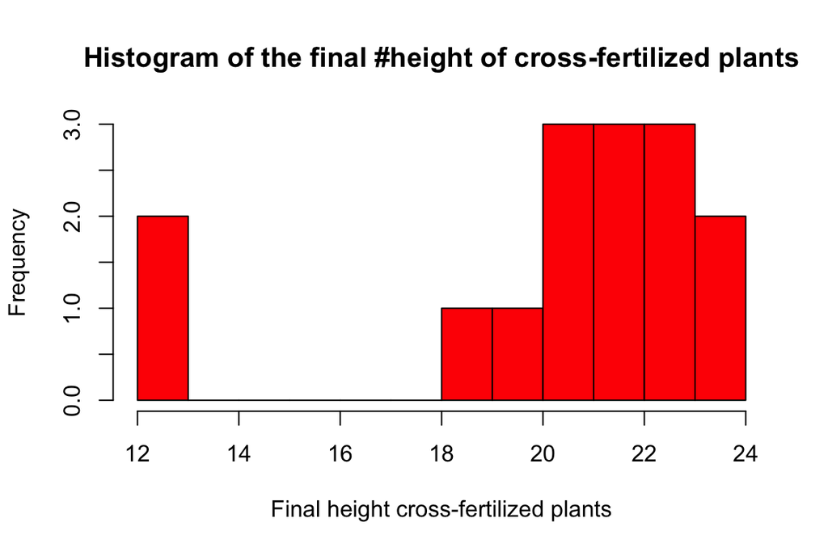

#### Code

```r
# load libraries
library(foreign)

# load dataset
Darwin <- read.spss('data/DARWIN.SAV', to.data.frame = TRUE)

# t-test for the difference between cross-fertilized and self-fertilized plants
t.test(Darwin$FH_CROSS, Darwin$FH_SELF, paired = TRUE)
```

#### Output

```r
t.test(Darwin$FH_CROSS, Darwin$FH_SELF, paired = TRUE)
```

```
##
##  Paired t-test
##
## data:  Darwin$FH_CROSS and Darwin$FH_SELF
## t = 2.1422, df = 14, p-value = 0.05025
## alternative hypothesis: true difference in means is not equal to 0
## 95 percent confidence interval:
##  -0.003205724  5.216539057
## sample estimates:
## mean of the differences
##                2.606667
```

#### Discussion

There are four assumptions of the paired t-test:  
- The dependent variable must be continuous (interval/ratio).  
- The observations are independent of one another.  
- The dependent variable should be approximately normally distributed.  
- The dependent variable should not contain any outliers.  
The histogram of the final heights of the cross-fertilized plant shows the data is not normally distributed. Therefore, we use non-parametric methods in question b and c of this exercise.

### Question b

Test the hypothesis of no difference in final height between cross-fertilized and self-fertili?zed plants with Wilcoxon’s signed rank test. Use the function `wilcox.test()`

#### Hints

Set te parameter `paired = TRUE` in `wilcox.test()` to perform the paired test. Otherwise, `wilcox.test()` will perform a Mann-Whitney U-test.

#### Code

```r
wilcox.test(Darwin$FH_CROSS, Darwin$FH_SELF, paired = TRUE)
```

#### Output

```r
wilcox.test(Darwin$FH_CROSS, Darwin$FH_SELF, paired = TRUE)
```

```
##
##  Wilcoxon signed rank test
##
## data:  Darwin$FH_CROSS and Darwin$FH_SELF
## V = 96, p-value = 0.04126
## alternative hypothesis: true location shift is not equal to 0
```

### Question c

What is the median difference in final height between cross-fertilized and self-fertilized plants? Test the hypothesis that the median difference is equal to zero. Give an exact confidence interval for the median difference. Use the appropriate table from the Appendix.

#### Hints

The null hypothesis of the Wilcoxon’s signed rank test is that the median difference is 0, thus you can use that test.

#### Code

```r
wilcox.test(Darwin$FH_CROSS, Darwin$FH_SELF, paired = TRUE, conf.int = TRUE)
```

#### Output

```r
wilcox.test(Darwin$FH_CROSS, Darwin$FH_SELF, paired = TRUE, conf.int = TRUE)
```

```
##
##  Wilcoxon signed rank test
##
## data:  Darwin$FH_CROSS and Darwin$FH_SELF
## V = 96, p-value = 0.04126
## alternative hypothesis: true location shift is not equal to 0
## 95 percent confidence interval:
##  0.45 5.20
## sample estimates:
## (pseudo)median
##          3.125
```

#### Discussion

By default (if the parameter `exact` is not specified), `wilcox.test()` computes an exact p-value if the samples contain less than 50 finite values and there are no ties. Otherwise, R gives the P-value based on normal approximations. You can check the exact P-value in the appropriate table from the Appendix.

##### The exact test

```r
wilcox.test(Darwin$FH_CROSS, Darwin$FH_SELF, paired = TRUE, conf.int = TRUE, exact = TRUE)
```

```
##
##  Wilcoxon signed rank test
##
## data:  Darwin$FH_CROSS and Darwin$FH_SELF
## V = 96, p-value = 0.04126
## alternative hypothesis: true location shift is not equal to 0
## 95 percent confidence interval:
##  0.45 5.20
## sample estimates:
## (pseudo)median
##          3.125
```

##### The test using normal approximations.

```r
wilcox.test(Darwin$FH_CROSS, Darwin$FH_SELF, paired = TRUE, conf.int = TRUE, exact = FALSE)
```

```
##
##  Wilcoxon signed rank test with continuity correction
##
## data:  Darwin$FH_CROSS and Darwin$FH_SELF
## V = 96, p-value = 0.04377
## alternative hypothesis: true location shift is not equal to 0
## 95 percent confidence interval:
##  0.05003166 5.24991389
## sample estimates:
## (pseudo)median
##       3.075224
```

## Exercise 7: Trend Test

The data file BACKPAIN (see page A3) contains data from a trial on the treatment of chronic low back pain. 100 patients were randomized to one out of four treatment groups:

| Blockage | Medication Bupivacaine | Medication Bupivacaine_Tramcinolon | Medication Total |
| --- | --- | --- | --- |
| Nerve root only | 25 | 25 | 50 |
| Nerve root_Facetoint | 24 | 26 | 50 |
| Total | 49 | 51 | 100 |

Note:  
Group 1: Bupivacaine + Nerve root only;  
Group 2: Bupivacaine_Tramcinolon + Nerve root only;  
Group 3: Bupivacaine + Nerve root_Facetoint;  
Group 4: Bupivacaine_Tramcinolon + Nerve root_Facetoint

One of the outcomes analyzed was the ‘hours pain per day’ (HPD). The maximum score for this outcome was set to 16. It was measured three days before the blockade (T = 0) and 6 weeks after the blockade (T = 1). (In reality the follow-up was longer.)

### Question a

Open the data file, get familiar with the different variables. Examine per group how the HPD-scores at baseline (T = 0) are distributed. How would you describe the scores?

#### Hints

Split the data per group Using the `subset()` function and plot HDP0 histograms (using the same scale) with the `hist()` function. In order to compare the distribution of the HDP0 scores, it could be handy to have all plots as panels in the same figure. For doing this use `par(mfrow = c(number_of_rows,number_of_columns))`

#### Code

```r
library(foreign) #load libraries

Backpain <- read.spss("./data/Backpain.sav", to.data.frame = TRUE) # read Data

# Familiarize with the data
head(Backpain)   # first 6 rows of the dataset
dim(Backpain)    # dimensions of the dataset
summary(Backpain)

# create subdatsets for each of the 4 groups
bup      <- subset(Backpain, Backpain$GROUP == "nerve+Bupivacaine")
buptram  <- subset(Backpain, Backpain$GROUP == "nerve+Bupivacaine+Tramcinolon")
bupfacet <- subset(Backpain, Backpain$GROUP == "nerve+facetjoint+Bupivacaine")
buptramfacet <- subset(Backpain, Backpain$GROUP == "nerve+facetjoint+Bupivacaine+Tramcinolon")

# plot in four panels (2 rows and 2 columns) the SCORE, and set the Y axis to the same limit to help the comparison
par(mfrow = c(2, 2))
hist(bup$HPD0, ylim = c(0, 20), main = "nerve+Bupivacaine")
hist(buptram$HPD0, ylim = c(0, 20), main = "nerve+Bupivacaine+Tramcinolon")
hist(bupfacet$HPD0, ylim = c(0, 20), main = "nerve+facetjoint+Bupivacaine")
hist(buptramfacet$HPD0, ylim = c(0, 20), main = "nerve+facetjoint+Bupivacaine+Tramcinolon")
```

#### Output

```r
library(foreign) #load libraries
Backpain <- read.spss("./data/Backpain.sav", to.data.frame = TRUE) #read fata

# Familiarize with the data
head(Backpain)  # first 6 rows of the dataset
```

```
##   PATNO                                    GROUP HPD0 HPD1
## 1     1             nerve+facetjoint+Bupivacaine   16   16
## 2     2 nerve+facetjoint+Bupivacaine+Tramcinolon    6   16
## 3     3                        nerve+Bupivacaine    2    3
## 4     4                        nerve+Bupivacaine    3   10
## 5     5            nerve+Bupivacaine+Tramcinolon   10    9
## 6     6             nerve+facetjoint+Bupivacaine    8    5
```

```r
dim(Backpain)   # dimensions of the dataset
```

```
## [1] 100   4
```

```r
summary(Backpain)
```

```
##      PATNO                                             GROUP
##  Min.   :  1.00   nerve+Bupivacaine                       :25
##  1st Qu.: 25.75   nerve+Bupivacaine+Tramcinolon           :25
##  Median : 50.50   nerve+facetjoint+Bupivacaine            :24
##  Mean   : 50.50   nerve+facetjoint+Bupivacaine+Tramcinolon:26
##  3rd Qu.: 75.25
##  Max.   :100.00
##
##       HPD0            HPD1
##  Min.   : 2.00   Min.   : 0.00
##  1st Qu.:12.00   1st Qu.: 4.00
##  Median :16.00   Median :14.00
##  Mean   :13.55   Mean   :10.25
##  3rd Qu.:16.00   3rd Qu.:16.00
##  Max.   :16.00   Max.   :16.00
##                  NA's   :3
```

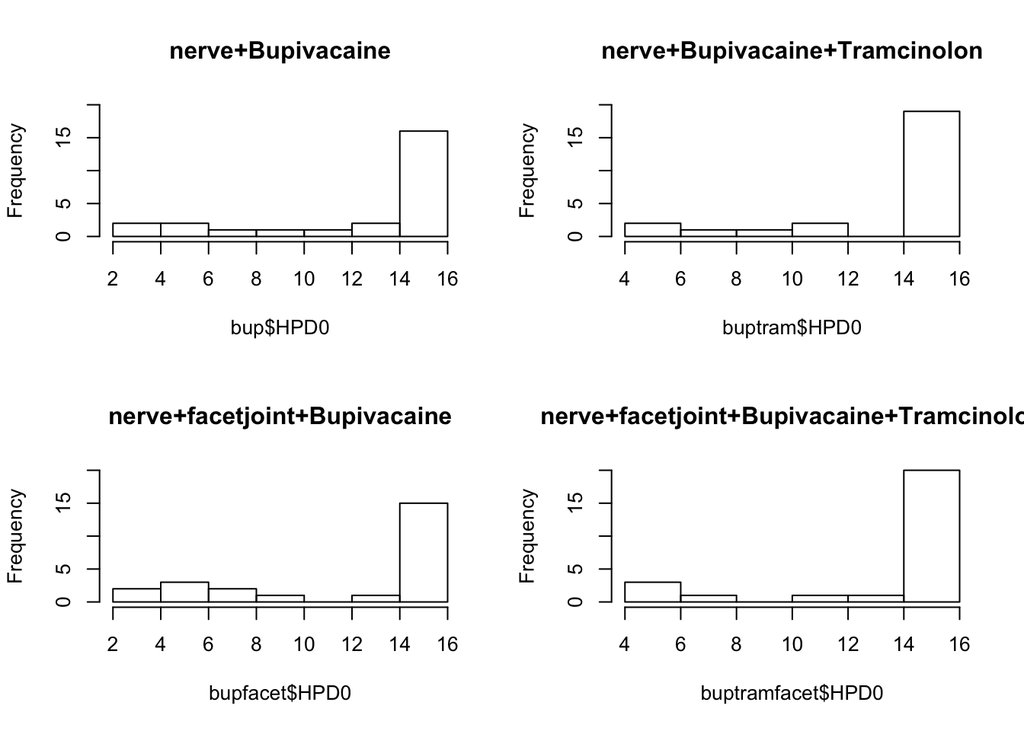

```r
# create subdatsets for each of the 4 groups
bup      <- subset(Backpain, Backpain$GROUP == "nerve+Bupivacaine")
buptram  <- subset(Backpain, Backpain$GROUP == "nerve+Bupivacaine+Tramcinolon")
bupfacet <- subset(Backpain, Backpain$GROUP == "nerve+facetjoint+Bupivacaine")
buptramfacet <- subset(Backpain, Backpain$GROUP == "nerve+facetjoint+Bupivacaine+Tramcinolon")

# plot in four panels (2 rows and 2 columns) the SCORE, and set the Y axis to the same limit to help the comparison
par(mfrow = c(2,2))
hist(bup$HPD0, ylim = c(0, 20), main = "nerve+Bupivacaine")
hist(buptram$HPD0, ylim = c(0, 20), main = "nerve+Bupivacaine+Tramcinolon")
hist(bupfacet$HPD0, ylim = c(0, 20), main = "nerve+facetjoint+Bupivacaine")
hist(buptramfacet$HPD0, ylim = c(0, 20), main = "nerve+facetjoint+Bupivacaine+Tramcinolon")
```

#### Discussion

The score is not normally distributed in the different groups. Also, the HGD0-score distributions seem quite similar accross the groups.

### Question b

Use the appropriate test to check for a difference of the scores at baseline between the four groups.

#### Hints

As the scores are not normally distributed, we need to use non-parametric tests (i.e. the Kruskal-Wallis Test). With this kind of tests, we can decide whether the population distributions are identical without assuming them to follow the normal distribution. An appropriate test then is the Kruskal-Wallis. Therefore, we can use the `kruskal.test()` function.

#### Code

```r
# Performs Kruskal-Wallis accross groups
kruskal.test(HPD0 ~ GROUP, data = Backpain)
```

#### Output

```r
# Performs Kruskal-Wallis accross groups
kruskal.test(HPD0 ~ GROUP, data = Backpain)
```

```
##
##  Kruskal-Wallis rank sum test
##
## data:  HPD0 by GROUP
## Kruskal-Wallis chi-squared = 2.972, df = 3, p-value = 0.396
```

#### Discussion

The null hypothesis is “There is no difference in HGD0 across groups”. The p-value is 0.396, therefore, we do not reject the null hypothesis i.e. there is no significant difference in HGD0 across the groups. This is in line with the visual inspection under question a.

### Question c

We restrict the following analyses to group 1 and 3 now. First, test for both groups separately whether the blockade resulted in an improvement compared to the baseline.

#### Hints

One easy way to visualize this question is by creating a new variable in which we can save the difference in scores between T=1 and T=0. After doing this, we can statistically test the effect of the blockade in each of these groups.

Remember, the scores are not normally distributed, therefore, we need to use a non-parametric test, such as the Wilcoxon test. As we are comparing the same individuals at two different time points we need to use a PAIRED version of the test. Use the function `wilcox.test()` with the appropriate flag.

#### Code

```r
# First group
bup$diff <- bup$HPD0 - bup$HPD1
summary(bup)
# HPD0 is higher than HPD1 in a majority of cases, this can be visually represented
# NOte one of the values is NA therefore only 24 individuals are considered
par(mfrow = c(1, 1))
plot(bup$diff, xlim = range(0:25), ylim = range(-20:20), pch = 19, ylab = "HDP0-HDP1")
# add a line at 0
abline(h = 0, col = 2)

# ties 7, higher HDP0: 11, higher HDP1:6
# We use a non-parametric paired test as we have repeated measurements in the same persons
wilcox.test(bup$HPD0, bup$HPD1, paired = TRUE)

# Third group
bupfacet$diff <- bupfacet$HPD0 - bupfacet$HPD1
summary(bupfacet)
plot(bupfacet$diff, xlim = range(0:25), ylim = range(-20:20), pch = 19, ylab = "HDP0-HDP1")
abline(h = 0, col = 2)# add a line at 0

#results seem much more tight. 13 ties, 2 higher HDP1 and 9 higher HDP0.
wilcox.test(bupfacet$HPD0, bupfacet$HPD1, paired=TRUE)
```

#### Output

```r
# First group
bup$diff <- bup$HPD0 - bup$HPD1
summary(bup)
```

```
##      PATNO                                           GROUP
##  Min.   : 3.0   nerve+Bupivacaine                       :25
##  1st Qu.:25.0   nerve+Bupivacaine+Tramcinolon           : 0
##  Median :50.0   nerve+facetjoint+Bupivacaine            : 0
##  Mean   :49.6   nerve+facetjoint+Bupivacaine+Tramcinolon: 0
##  3rd Qu.:74.0
##  Max.   :97.0
##
##       HPD0            HPD1             diff
##  Min.   : 2.00   Min.   : 0.000   Min.   :-11.000
##  1st Qu.:12.00   1st Qu.: 4.500   1st Qu.: -0.250
##  Median :16.00   Median : 9.000   Median :  0.000
##  Mean   :13.12   Mean   : 9.458   Mean   :  3.542
##  3rd Qu.:16.00   3rd Qu.:16.000   3rd Qu.: 10.250
##  Max.   :16.00   Max.   :16.000   Max.   : 16.000
##                  NA's   :1        NA's   :1
```

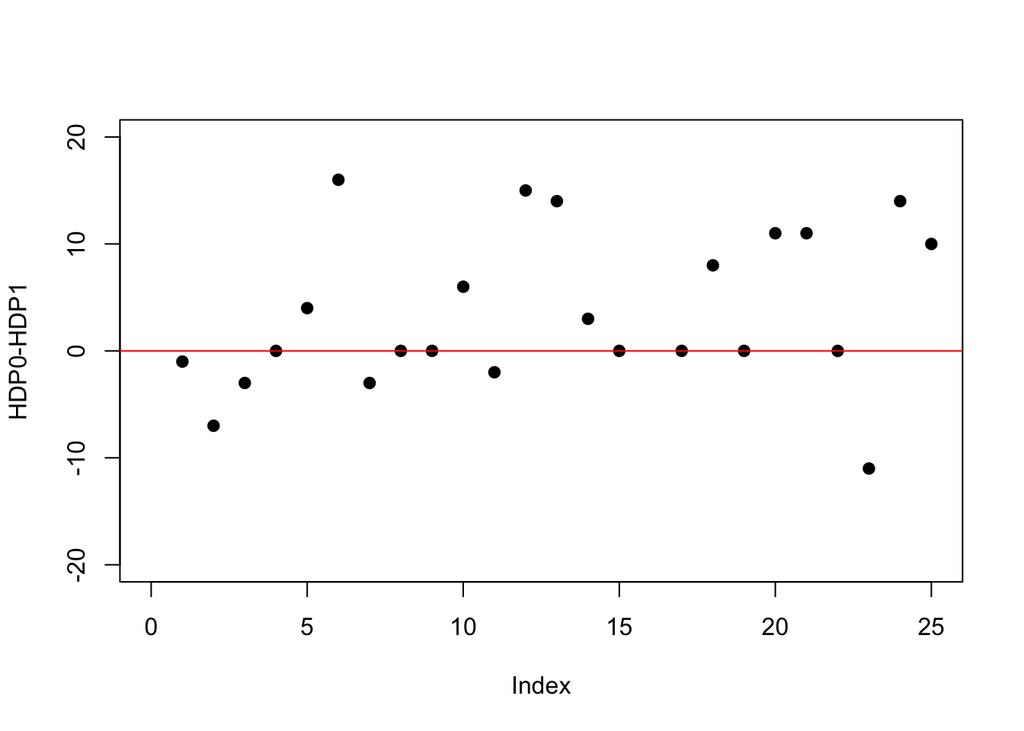

```r
# HPD0 is higher than HPD1 in a majority of cases, this can be visually represented
# NOte one of the values is NA therefore only 24 individuals are considered
par(mfrow = c(1, 1))
plot(bup$diff, xlim = range(0:25), ylim = range(-20:20), pch = 19, ylab = "HDP0-HDP1")
abline(h = 0, col = 2) # add a line at 0
```

```r
# ties 7, higher HDP0: 11, higher HDP1:6
# we use a non-parametric paired test as we have repeated measurements in the same persons
wilcox.test(bup$HPD0, bup$HPD1, paired=TRUE)
```

```
##
##  Wilcoxon signed rank test with continuity correction
##
## data:  bup$HPD0 and bup$HPD1
## V = 122, p-value = 0.03293
## alternative hypothesis: true location shift is not equal to 0
```

```r
##Third group
bupfacet$diff <- bupfacet$HPD0 - bupfacet$HPD1
summary(bupfacet)
```

```
##      PATNO                                            GROUP
##  Min.   : 1.00   nerve+Bupivacaine                       : 0
##  1st Qu.:26.25   nerve+Bupivacaine+Tramcinolon           : 0
##  Median :49.50   nerve+facetjoint+Bupivacaine            :24
##  Mean   :48.58   nerve+facetjoint+Bupivacaine+Tramcinolon: 0
##  3rd Qu.:72.25
##  Max.   :93.00
##       HPD0            HPD1            diff
##  Min.   : 3.00   Min.   : 1.00   Min.   :-10.000
##  1st Qu.: 8.00   1st Qu.: 4.75   1st Qu.:  0.000
##  Median :16.00   Median :16.00   Median :  0.000
##  Mean   :12.58   Mean   :11.40   Mean   :  1.188
##  3rd Qu.:16.00   3rd Qu.:16.00   3rd Qu.:  2.000
##  Max.   :16.00   Max.   :16.00   Max.   : 14.000
```

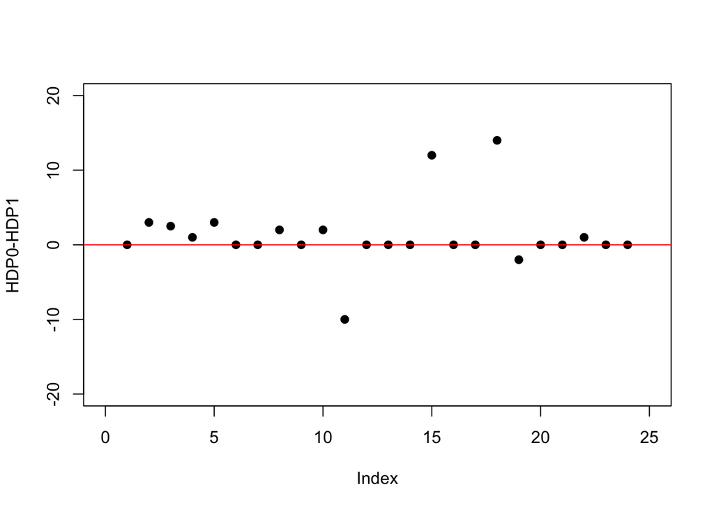

```r
plot(bupfacet$diff, xlim = range(0:25), ylim = range(-20:20), pch = 19, ylab = "HDP0-HDP1")
# add a line at 0
abline(h = 0, col = 2)
```

```r
# results seem much more tight. 13 ties, 2 higher HDP1 and 9 higher HDP0.
wilcox.test(bupfacet$HPD0, bupfacet$HPD1, paired=TRUE)
```

```
##
##  Wilcoxon signed rank test with continuity correction
##
## data:  bupfacet$HPD0 and bupfacet$HPD1
## V = 53, p-value = 0.08205
## alternative hypothesis: true location shift is not equal to 0
```

#### Discussion

For the first group, the hours of pain are significantly reduced p-value = 0.03 after treatment with Bupivacaine and Nerve Root blockage. However, for the third group we cannot reject the null hypothesis, p-value = 0.08, we have no evidence that the difference in pain hours at baseline and after treatment are not by chance.

### Question d

Test whether there is a significant difference in improvement between group 1 and group 3.

#### Hints

As we created already a variable with the difference in HDP between T=1 and T=0, this is straight forward.

Take into account that this time you are comparing two different treatments, and therefore, independent individuals. As for the previous question we can use the `wilcox.test()` fuction. No need for the `paired =` flag though.

#### Code

```r
# Now we are testing independent individuals so there is no need to use the flag for paired individuals

wilcox.test(bup$diff, bupfacet$diff)
```

#### Output

```r
# Now we are testing independent individuals so there is no need to use the flag for paired individuals

wilcox.test(bup$diff, bupfacet$diff)
```

```
##
##  Wilcoxon rank sum test with continuity correction
##
## data:  bup$diff and bupfacet$diff
## W = 314, p-value = 0.585
## alternative hypothesis: true location shift is not equal to 0
```

#### Discussion

The p-value is 0.585, therefore we do not reject the null hypothesis. There is no significant difference in improvement between the individuals in group 1 and those in group 3.

## Exercise 8: Confidence interval for a proportion

In this exercise, we will use the blood pressure data set again, BLDPRES.SAV. We now want to get a confidence interval for the prevalence of high blood pressure, defined as, diastolic blood pressure above 90 mmHg.

Take a quick look at what the BLDPRES dataset contains:

BLDPRES dataset

| age | sys | dias | weight | pulse | sex | ses | RES_1 | res_2 |
| --- | --- | --- | --- | --- | --- | --- | --- | --- |
| 28 | 130.0 | 75.0 | 49 | 72 | female | upperclass | 9.251631 | 85.592683 |
| 24 | 117.5 | 72.5 | 54 | 80 | female | upperclass | -1.659402 | 2.753614 |
| 65 | 115.0 | 70.0 | 50 | 80 | female | upperclass | -20.446313 | 418.051707 |
| 32 | 125.0 | 87.5 | 61 | 88 | female | upperclass | 2.662664 | 7.089782 |
| 23 | 127.5 | 87.5 | 67 | 76 | female | upperclass | 8.737840 | 76.349848 |

### Question a

We are going to compute again the variable highbp (highbp is 0 if dias<= 90 and 1 if dias > 90).

#### Hints

If you don’t remember how to do this: see Exercise 5b.

#### Code

```r
#load libraries
library(foreign)

#read Data
BLDPRES <- read.spss("./data/BLDPRES.sav", to.data.frame=TRUE)

# create a new variable
BLDPRES$highbp <- c()
BLDPRES$highbp[BLDPRES$dias <= 90] <- 0
BLDPRES$highbp[BLDPRES$dias > 90] <- 1

# to familiarize with the data
summary(BLDPRES)
```

#### Output

```
##       age             sys             dias            weight
##  Min.   :20.00   Min.   : 85.0   Min.   : 57.50   Min.   : 27.00
##  1st Qu.:26.00   1st Qu.:115.0   1st Qu.: 75.00   1st Qu.: 43.00
##  Median :35.00   Median :122.5   Median : 80.00   Median : 49.00
##  Mean   :39.12   Mean   :125.2   Mean   : 81.12   Mean   : 51.28
##  3rd Qu.:50.00   3rd Qu.:132.5   3rd Qu.: 87.50   3rd Qu.: 58.00
##  Max.   :81.00   Max.   :195.0   Max.   :110.00   Max.   :102.00
##      pulse            sex                 ses          RES_1
##  Min.   : 40.00   male  :145   lower class  :138   Min.   :-50.446
##  1st Qu.: 72.00   female:183    middle class:127   1st Qu.:-10.375
##  Median : 84.00                upperclass   : 63   Median : -1.053
##  Mean   : 82.15                                    Mean   :  0.000
##  3rd Qu.: 88.00                                    3rd Qu.:  8.486
##  Max.   :120.00                                    Max.   : 55.581
##      res_2             highbp
##  Min.   :   0.00   Min.   :0.0000
##  1st Qu.:  22.10   1st Qu.:0.0000
##  Median :  94.46   Median :0.0000
##  Mean   : 265.11   Mean   :0.1402
##  3rd Qu.: 290.88   3rd Qu.:0.0000
##  Max.   :3089.28   Max.   :1.0000
```

#### Discussion

This one was easy to perform!

### Question b

How many people have high blood pressure? Express this value as a proportion. Verify whether the sample mean is indeed the same as the sample prevalence of high blood pressure. Now get a confidence interval for the prevalence of high blood pressure. Remark: This confidence interval can be calculated based on different distributions. In this case, we will calculate it based on the standard normal distribution, as our sample size is large.

#### Hints

For the first part let’s use functions `table()` and `prop.table()`.

The calculation of the confidence interval can be a bit tricky. Remember how you define the confidence interval of a proportion (p) based on a normal distribution: $95\% CI = p \pm 1.96 \sqrt\frac{p(1-p)} {N}$

#### Code

```r
# number of individuals with normal and high BP
table(BLDPRES$highbp)

# now the same indices but in percentages
prop.table(table(BLDPRES$highbp))

# compare with the mean of the variable
mean(BLDPRES$highbp)

# Lets use now the normal distribution to calculate the Z statistic (this number is very used in statistics so you can even memorize it)
alpha <- 0.05
z <- qnorm(1 - alpha / 2)

# Compute the CI
p <- 0.1402439 # sample prevalence of high blood pressure
N <- 328       # sample size
p + c(-1, 1) * z * sqrt(p * (1 - p) / N)
```

#### Output

```r
# number of individuals with normal and high BP
table(BLDPRES$highbp)
```

```
##
##   0   1
## 282  46
```

```r
# now the same indices but in percentages
prop.table(table(BLDPRES$highbp))
```

```
##
##         0         1
## 0.8597561 0.1402439
```

```r
# compare with the mean of the variable
mean(BLDPRES$highbp)
```

```
## [1] 0.1402439
```

```r
# Lets use now the normal distribution to calculate the Z statistic (this number is very used in statistics so you can even memorize it)
alpha <- 0.05
z <- qnorm(1 - alpha / 2)

# Compute the CI
p <- 0.1402439 # sample prevalence of high blood pressure
N <- 328       # sample size
p + c(-1, 1) * z * sqrt(p * (1 - p) / N)
```

```
## [1] 0.1026653 0.1778225
```

#### Discussion

There is a prevalence of high BP of 0.14, this value can be calculated in different ways. The 95% confidence interval for this proportion is [0.1026, 0.1778].

### Question c

Assume that you know that in your own country the prevalence of people with high blood pressure is 18%. Can we claim that in this area of Pakistan that the prevalence is lower? Perform the appropriate test and specify the cut point from the definition above. Check in the output carefully whether you have specified the correct ‘hypothesized proportion’.

#### Hints

Use the function `binom.test()` with the appropriate flag as the problem suggests using a one-sided test. Check `?binom.test()` to see which arguments do you need to use for this function.

#### Code

```r
## this question proposed a one-sided test, is the calculated proportion significantly less than 0.18?
## In this case, we use the binomial test fixing the comparison value to 0.18
binom.test(46, 328, p = 0.18, alternative = "less", conf.level = 0.95)
```

#### Output

```r
## this question proposed a one-sided test, is the calculated proportion significantly less than 0.18?
##  In this case, we use the binomial test fixing the comparison value to 0.18
binom.test(46, 328, p = 0.18, alternative = "less", conf.level = 0.95)
```

```
##
##  Exact binomial test
##
## data:  46 and 328
## number of successes = 46, number of trials = 328, p-value =
## 0.03279
## alternative hypothesis: true probability of success is less than 0.18
## 95 percent confidence interval:
##  0.0000000 0.1757363
## sample estimates:
## probability of success
##              0.1402439
```

#### Discussion

The high BP prevalence reported for this region of Pakistan (14%) is significantly lower than 18% reported from my country of origin.

## Exercise 9: Trend test

The file COLON.SAV contains data regarding disease evolution of patients with a colon or rectum carcinoma. In this exercise, we will select only the male patients and examine the relation between stage of the tumor (i.e., the higher the stage the more extensive the tumor is) and weight loss.

Take a quick look at what the COLON dataset contains:

COLON dataset

| AGE | SEX | CHANCE | PATTERN | BLDLOSS | STOMACHE | WGHTLOSS | ILEUS | STATUS | STAGE | LOC | SURV | OPYEAR | AGEGR |
| --- | --- | --- | --- | --- | --- | --- | --- | --- | --- | --- | --- | --- | --- |
| 74 | female | 0 | 0 | 0 | 0 | 1 | 0 | 0 | 2 | colon transcendent | 9.191 | 72 | >70 |
| 63 | male | 0 | 1 | 1 | 0 | 0 | 0 | 1 | 4 | colon descendent | 0.419 | 62 | 60-70 |
| 80 | male | 0 | 1 | 1 | 1 | 1 | 0 | 1 | 2 | colon descendent | 3.058 | 63 | >70 |
| 76 | female | 0 | 0 | 0 | 1 | 0 | 0 | 1 | 2 | coecum | 1.927 | 63 | >70 |
| 25 | female | 0 | 1 | 1 | 1 | 0 | 1 | 1 | 4 | rectum | 0.931 | 66 | <=60 |

### Question a

Create a new dataset selecting only the males in the COLON dataset.

#### Hints

Use the function `subset()`.

#### Code

```r
library(foreign) #load libraries
COLON <- read.spss("./data/COLON.sav", to.data.frame = TRUE) # read Data


colon_males <- subset(COLON, COLON$SEX == "male") # slect only males
head(colon_males)
```

#### Output

```
##    AGE  SEX CHANCE PATTERN BLDLOSS STOMACHE WGHTLOSS ILEUS STATUS STAGE
## 2   63 male      0       1       1        0        0     0      1     4
## 3   80 male      0       1       1        1        1     0      1     2
## 8   71 male      0       1       0        0        1     0      1     4
## 12  75 male      0       1       0        0        1     0      1     4
## 13  71 male      0       0       1        1        0     0      0     1
## 17  68 male      1       0       0        0        0     0      1     4
##                   LOC  SURV OPYEAR AGEGR
## 2    colon descendent 0.419     62 60-70
## 3    colon descendent 3.058     63   >70
## 8    colon descendent 0.860     72   >70
## 12 colon transcendent 0.734     78   >70
## 13   colon descendent 3.781     78   >70
## 17   colon descendent 0.726     78 60-70
```

#### Discussion

This one was easy to perform!

### Question b

Create the crosstable of weight loss versus stage, including the percentages with weight loss within each stage group. Examine these percentages. Does this suggest a trend?

#### Hints

For the first part lets use functions `table()` and `prop.table()`.

To test the proportion difference use `prop.test()`.

Create a table binding these results and adding a column with the total number of people per stage (to ease interpretation, you will use this table also in following questions of this exercise)

#### Code

```r
stage_wghtloss <- table(colon_males$STAGE, colon_males$WGHTLOSS)
stage_wghtloss

# now the same indices but in percentages
freq <- prop.table(stage_wghtloss, 1)
freq

# combine them in one table
combined <- as.data.frame(cbind(stage_wghtloss, freq))
names(combined) <- c("no_change", "weight_loss", "%_no_change", "%_weight_loss")
combined$total  <- combined$weight_loss + combined$no_change
combined
```

#### Output

```r
stage_wghtloss <- table(colon_males$STAGE, colon_males$WGHTLOSS)
stage_wghtloss
```

```
##
##      0  1
##   1 58 16
##   2 72 29
##   3 32 14
##   4 41 25
```

```r
# now the same indices but in percentages
freq <- prop.table(stage_wghtloss, 1)
freq
```

```
##
##             0         1
##   1 0.7837838 0.2162162
##   2 0.7128713 0.2871287
##   3 0.6956522 0.3043478
##   4 0.6212121 0.3787879
```

```r
# combine them in one table
combined <- as.data.frame(cbind(stage_wghtloss, freq))
names(combined) <- c("no_change", "weight_loss", "%_no_change", "%_weight_loss")
combined$total <- combined$weight_loss + combined$no_change
combined
```

```
##   no_change weight_loss %_no_change %_weight_loss total
## 1        58          16   0.7837838     0.2162162    74
## 2        72          29   0.7128713     0.2871287   101
## 3        32          14   0.6956522     0.3043478    46
## 4        41          25   0.6212121     0.3787879    66
```

#### Discussion

It seems that as you increase in stage, the percentage of individuals with weight loss also increases.

### Question c

Now, let’s test if the observed trend is statistically significant. In order to do this we will use two different methods: 1) a chi-square test and 2) trend test. Look carefully at the output of both tests. Can you identify what is the difference between these tests? Why is the number of degrees of freedom different? What is your conclusion about the relation?

In order to see whether this trend test depends on the values attached to the categories of stage (now: 1, 2, 3 and 4), recode these values to: 1, 2, 100, 1000. See what happens with the significance of the test. What is your conclusion?

#### Hints

Use the function `prop.test()` for the chi-square test, and the `prop.trend.test()` for the trend test. You can use the `combined` dataset which you just created at Question b. Note that this last test has the option to change the score flag (you can then recode categories of the `STAGE` variable).

#### Code

```r
#chi squared test
prop.test(combined$weight_loss, combined$total)

#Trend test with the original score codes
prop.trend.test(combined$weight_loss, combined$total, score = c(1, 2, 3, 4))

#Test wether the trend test depends on the "score" values, recode them.
prop.trend.test(combined$weight_loss, combined$total, score = c(1, 2, 100, 1000))
```

#### Output

```
##
##  4-sample test for equality of proportions without continuity
##  correction
##
## data:  combined$weight_loss out of combined$total
## X-squared = 4.4991, df = 3, p-value = 0.2124
## alternative hypothesis: two.sided
## sample estimates:
##    prop 1    prop 2    prop 3    prop 4
## 0.2162162 0.2871287 0.3043478 0.3787879
```

```
##
##  Chi-squared Test for Trend in Proportions
##
## data:  combined$weight_loss out of combined$total ,
##  using scores: 1 2 3 4
## X-squared = 4.3015, df = 1, p-value = 0.03808
```

```
##
##  Chi-squared Test for Trend in Proportions
##
## data:  combined$weight_loss out of combined$total ,
##  using scores: 1 2 100 1000
## X-squared = 3.2393, df = 1, p-value = 0.07189
```

#### Discussion

Based on the chi-square results, one will claim there are no significant differences accross the different stages (p = 0.212). However, the trend test with the original scoring of the stages show that there was a significant trend! (p = 0.038), this is because actually the chi-quare compares all groups and thus, you make use of 3 degrees of freedom ($\chi$-square test compares 4 groups, so df = 4 - 1 = 3). While in the trend test you are using just one degree of freedom by testing the slope of one line. Therefore, there is a linear trend, but the groups do not differ significantly.

Changing the codes of the stage categories resulted in a non significant trend (p = 0.072). In other words, if you would now draw a line through the points it will be less steep (slope is smaller), and not significant. This is one of the main critics for the trend tests as they will depend on how you score the categories.

### Question d

As an alternative trend test, Wilcoxon’s two-sample test (Mann-Whitney) might be used. Which variable determines the two groups, and which variable is to be tested? Apply the test and compare the results. What is an essential difference with the trend test?

#### Hints

We need first to create the column with the recoded `STAGE` (i.e, `STAGE_new`), as explained in question c (i.e., 1, 2, 100, 1000) in the original data colon_males Use the and .

Then we can use the function `wilcox.test()` in the `STAGE` and `STAGE_new` variables

#### Code

```r
wilcox.test(colon_males$STAGE ~ as.factor(colon_males$WGHTLOSS))

## now recode the STAGE in STAGE_new and run the non-parametric test
wilcox.test(colon_males$STAGE_new ~ as.factor(colon_males$WGHTLOSS))
```

#### Output

```
##
##  Wilcoxon rank sum test with continuity correction
##
## data:  colon_males$STAGE by as.factor(colon_males$WGHTLOSS)
## W = 7255.5, p-value = 0.03879
## alternative hypothesis: true location shift is not equal to 0
```

```
##
##  Wilcoxon rank sum test with continuity correction
##
## data:  colon_males$STAGE_new by as.factor(colon_males$WGHTLOSS)
## W = 7255.5, p-value = 0.03879
## alternative hypothesis: true location shift is not equal to 0
```

#### Discussion

As you could see in the code, the outcome is now `STAGE` and the exposure `WGHTLOSS` (p = 0.03879). This test suggest that there is a significant difference in the proportion of individuals who lost weight accross stages. Changing the codes of the stage categories did not change the results (p = 0.03879). This test does not consider the variable as values, but just as consecutive categories.

## Exercise 10: Paired dichotomous data

We will use the data set Schizo.sav in this exercise. A group of 100 psychiatric patients is screened for schizophrenia by two psychiatrists, independently. Let’s assume the true disease status of the patients is known to us. We now want to compare the sensitivity of the two psychiatrists (i.e. proportion of schizophrenic patients correctly diagnosed by each psychiatrist).

Start loading the data from the Schizo.sav file using `read.spss` and call the data `schizo`.

### Question a

Make a frequency table of the true disease status. How many schizophrenic patients are there? Select this group. What percentage did psychiatrist A correctly diagnose? And psychiatrist B?

#### Code

```r
schizo <- read.spss("./data/Schizo.sav", to.data.frame = TRUE) # read Data
summary(schizo$SIT) # makes a frequency table of the true disease status

schizo_pos <- schizo[schizo$SIT == "schizophrenia", ] # select the group of schizophrenic patients

##### psychiatrist A
ftA <- table(schizo_pos$SIT, schizo_pos$DIAGA) # returns a frequency table (counts)
prop.table(ftA) # calculates row percentages

##### psychiatrist B
ftB <- table(schizo_pos$SIT, schizo_pos$DIAGB) # returns a frequency table (counts)
prop.table(ftB) # calculates row percentages
```

#### Hints

Set your working directory and load the data “Schizo.sav”

Use functions `summary`, `table` and `prop.table` to make yourself familair with the data and to create the tables.

#### Output

```r
# read Data
schizo <- read.spss("./data/Schizo.sav", to.data.frame = TRUE)
summary(schizo$SIT) # makes a frequency table of the true disease status
```

```
## no schizophrenia    schizophrenia
##               35               65
```

```r
schizo_pos <- schizo[schizo$SIT == "schizophrenia", ] # select the group of schizophrenic patients

##### psychiatrist A
ftA <- table(schizo_pos$SIT,schizo_pos$DIAGA) # returns a frequency table (counts)
ptA <- prop.table(ftA) # calculates row percentages
ptA
```

```
##
##                    no schizophrenia schizophrenia
##   no schizophrenia        0.0000000     0.0000000
##   schizophrenia           0.1384615     0.8615385
```

```r
##### psychiatrist B
ftB <- table(schizo_pos$SIT,schizo_pos$DIAGB) # returns a frequency table (counts)
ptB <- prop.table(ftB) # calculates row percentages
ptB
```

```
##
##                    no schizophrenia schizophrenia
##   no schizophrenia        0.0000000     0.0000000
##   schizophrenia           0.2923077     0.7076923
```

#### Discussion

There are 65 patients with schizophrenia. Among the patients with schizophrenia, psychiatrist A diagnosed 86.2% correctly while psychiatrist B diagnosed 70.8% correctly.

### Question b

We now want to compare the two sensitivities. Create a cross table that displays the diagnoses made by each psychiatrist. Which patients were diagnosed identical by the two psychiatrists? Also perform a $\chi^2$-test. What hypothesis is tested? Formulate the conclusion of the test in your own words. Is this test relevant with respect to our research question (compare sensitivity)?

#### Code

```r
ct <- table(schizo_pos$DIAGA, schizo_pos$DIAGB)
ct
chisq.test(schizo_pos$DIAGA, schizo_pos$DIAGB, correct = FALSE) # Pearson chi square (two-sided)
```

#### Hints

With the `table` function you can see which patients were diagnosed identical by the two psychiatrists

The function `chisq.test` preforms the $\chi^2$-test

#### Output

```r
ct <- table(schizo_pos$DIAGA, schizo_pos$DIAGB)
ct
```

```
##
##                    no schizophrenia schizophrenia
##   no schizophrenia                2             7
##   schizophrenia                  17            39
```

```r
chisq.test(schizo_pos$DIAGA, schizo_pos$DIAGB, correct = FALSE) #Pearson chi square (two-sided)
```

```
##
##  Pearson's Chi-squared test
##
## data:  schizo_pos$DIAGA and schizo_pos$DIAGB
## X-squared = 0.24805, df = 1, p-value = 0.6185
```

#### Discussion

The null hypothesis is: “The diagnosis of schizophrenia performed by psychiatrist A has the same sensitivity as the diagnosis of schizophrenia performed by psychiatrist B”. The alternative hypothesis “The diagnosis of schizophrenia performed by psychiatrist A does not have the same sensitivity as the diagnosis of schizophrenia performed by psychiatrist B”. We have performed a two-sided $\chi^2$-test.

The p-value is 0.618, therefore we do not reject the null hypothesis, i.e. there is no significant difference between the sensitivity of the diagnosis performed by psychiatrist A and B.

### Question c

To test whether there is a significant difference in sensitivity, the McNemar test must be used. What is your conclusion?

#### Code

```r
mcnemar.test(ct, correct = TRUE)
```

#### Hints

The `mcnemar.test` function performs the McNemar test in `R`.

#### Output

```r
mcnemar.test(ct, correct = TRUE)
```

```
##
##  McNemar's Chi-squared test with continuity correction
##
## data:  ct
## McNemar's chi-squared = 3.375, df = 1, p-value = 0.06619
```

#### Discussion

The p-value is 0.066, therefore there is no statistically significant difference in sensitivity. This means that we can not reject the null hypothesis, which is “The diagnosis of schizophrenia performed by psychiatrist A has the same sensitivity as the diagnosis of schizophrenia performed by psychiatrist B”.

### Question d

In the question above (Question c) we used the McNemar test to look at what extent the ratio of the number of patients in the group “diagnose A positive, diagnose B negative (cell b)” to “diagnose A negative, diagnose B positive (cell c)” differs from 1. Can you think of another way of carrying out this test with `R`?

#### Code

```r
schizo_posAB <- schizo_pos[schizo_pos$DIAGB != schizo_pos$DIAGA, ] # select all columns and only rows with a different diagnosis by A and B

x <- sum(schizo_posAB$DIAGA == "schizophrenia") # number of times psychiatrist A diagnoses correctly patients with schizophrenia

binom.test(x, dim(schizo_posAB)[1], p = 0.5)
```

#### Hints

Another way is to only select patients with a different diagnosis by psychiatrist A and psychiatrist B. If there is no difference, in 50% of the cases the diagnosis by psychiatrist A is correct and in 50% psychiatrist B is correct.

Then you can use the Binominal test to check if the probability that psychiatrist A is correct is significantly different from 0.5.

#### Output

```r
schizo_posAB <- schizo_pos[schizo_pos$DIAGB != schizo_pos$DIAGA, ] # select all columns and only rows with a different diagnosis by A and B

x <- sum(schizo_posAB$DIAGA == "schizophrenia") # number of times psychiatrist A diagnoses correctly patients with schizophrenia

binom.test(x, dim(schizo_posAB)[1], p = 0.5)
```

```
##
##  Exact binomial test
##
## data:  x and dim(schizo_posAB)[1]
## number of successes = 17, number of trials = 24, p-value = 0.06391
## alternative hypothesis: true probability of success is not equal to 0.5
## 95 percent confidence interval:
##  0.4890522 0.8738479
## sample estimates:
## probability of success
##              0.7083333
```

#### Discussion

The p-value is 0.064, therefore we conclude that there is no significant difference between the proportion of correct diagnoses by A (among the patients diagnosed differently by the two psychiatrists) and 0.5 when using a significance level of 0.05.

### Question e

Calculate the mean of the difference in diagnosis in patients with schizophrenia between the two psychiatrists and calculate a 95% confidence interval for that mean. (NB: the coding is 1 for those assigned as having schizophrenia and 0 for those assigned of not having schizophrenia)

#### Code

```r
n <- dim(schizo_pos)[1]
schizo_pos$DIAGA_code <- ifelse(schizo_pos$DIAGA == "schizophrenia", 1, 0) # code schizophrenia
schizo_pos$DIAGB_code <- ifelse(schizo_pos$DIAGB == "schizophrenia", 1, 0) # code schizophrenia

schizo_pos$DIAGA_code - schizo_pos$DIAGB_code  # print the difference
m <- mean(schizo_pos$DIAGA_code - schizo_pos$DIAGB_code) # calculate the mean
sd <- sd(schizo_pos$DIAGA_code - schizo_pos$DIAGB_code)  # calculate the standard deviation
se <- sd / sqrt(n) # calculate the standard error

lower <- m - qt(0.975, n - 1) * se   # the lower bound of the 95%-CI
upper <- m + qt(0.975, n - 1) * se   # the upper bound of the 95%-CI

c(lower, m, upper)

# alternatively, use the t-test
t.test(schizo_pos$DIAGA_code, schizo_pos$DIAGB_code, paired = TRUE)
```

#### Hints

Use the Normal approximation method for the 95%-CI for the difference in proportions $(p_A-p_B)\pm1.96se(p_A-p_B)$. You can use the `sd()` function in `R` to calculate the standard deviation. The stanadard error in turn can be calculated `se <- sd/sqrt(n)`. To find the right number from the Student t Distribution you can use the following code `qt(0.975, n - 1)`.

#### Output

```r
n <- dim(schizo_pos)[1]
schizo_pos$DIAGA_code <- ifelse(schizo_pos$DIAGA == "schizophrenia", 1, 0) # code schizophrenia
schizo_pos$DIAGB_code <- ifelse(schizo_pos$DIAGB == "schizophrenia", 1, 0) # code schizophrenia

schizo_pos$DIAGA_code - schizo_pos$DIAGB_code  # print the difference
```

```
##  [1]  1  0  0  0  0  0  1  1  0  1  0  0  1  0  0  0  0  1 -1  0  0  0  0
## [24]  0  0  0  0  1  0  0  0  0  0  0  1  0  0  0  1  1 -1  1 -1  1  0  0
## [47]  0  0  0 -1 -1 -1  0  0 -1  1  1  1  0  1  0  0  0  0  1
```

```r
m <- mean(schizo_pos$DIAGA_code - schizo_pos$DIAGB_code) # calculate the mean
sd <- sd(schizo_pos$DIAGA_code - schizo_pos$DIAGB_code)  # calculate the standard deviation
se <- sd / sqrt(n) # calculate the standard error

lower <- m - qt(0.975, n - 1) * se   # the lower bound of the 95%-CI
upper <- m + qt(0.975, n - 1) * se   # the upper bound of the 95%-CI

c(lower, m, upper)
```

```
## [1] 0.007051648 0.153846154 0.300640659
```

```r
# alternatively, use the t-test
t.test(schizo_pos$DIAGA_code, schizo_pos$DIAGB_code, paired = TRUE)
```

```
##
##  Paired t-test
##
## data:  schizo_pos$DIAGA_code and schizo_pos$DIAGB_code
## t = 2.0937, df = 64, p-value = 0.04025
## alternative hypothesis: true difference in means is not equal to 0
## 95 percent confidence interval:
##  0.007051648 0.300640659
## sample estimates:
## mean of the differences
##               0.1538462
```

## Exercise 11: Clinical trial with dichotomous outcome

```r
aspirin <- read.spss("./data/Aspirin.sav", to.data.frame = TRUE) # load the data
```

You can do this exercise with a calculator, pencil and paper and/or with `R`. The data set is called aspirin.sav. When you load it in `R` call it aspirin.

Sixty-five pregnant women at high risk of pregnancy-induced hypertension participated in a randomised controlled clinical trial comparing the efficacy of 100 mg of aspirin daily with placebo during the third trimester of pregnancy in the prevention of hypertension. The observed number of women that did and did not develop hypertension are shown in the following table:

```r
table <- data.frame(Hypertension = c(5, 10), no.Hypertension = c(29, 21)) # create a table
row.names(table) <- c("Aspirin", "Placebo") # add row names
kable(table, align = 'c') # print the table
```

|  | Hypertension | no.Hypertension |
| --- | --- | --- |
| Aspirin | 5 | 29 |
| Placebo | 10 | 21 |

### Question a

Is the risk of hypertension in aspirin treated women significantly lower than in placebo treated women? Which test do you use and what is the p-value?

#### Code

```r
aspirin <- read.spss("./data/Aspirin.sav", to.data.frame = TRUE) # load data
chisq.test(aspirin$TREATM, aspirin$HYP, correct = FALSE) # perform a Chi-squared test
```

#### Hints

Use the $\chi^2$-test based on $\sum$(Observed-Expected)$^2/$Expected.

Expected counts are computed by multiplying the total by column and the total by row of a cell and dividing by the overall total. E.g. for the first cell. $\dfrac{34*15}{65}=7.8$.

$\chi^2= \dfrac{(5-7.8)^2}{7.8}+\dfrac{(29-26.2)^2}{26.2}+\dfrac{(10-7.2)^2}{7.2}+\dfrac{(2.1-23.8)^2}{23.8}=2.73$

Using the $\chi^2$ table find the row that corresponds to the relevant degrees of freedom (1). $\chi^2_{0.10}(1)=2.71<2.73<3.84=\chi^2_{0.05}(1)$ therefore $0.05<p<0.10$.

You can use `R` for the calculations above. You could also use the function `chisq.test`

#### Output

```r
aspirin <- read.spss("./data/Aspirin.sav", to.data.frame = TRUE) # load data
chisq.test(aspirin$TREATM, aspirin$HYP, correct = FALSE)
```

```
##
##  Pearson's Chi-squared test
##
## data:  aspirin$TREATM and aspirin$HYP
## X-squared = 2.8142, df = 1, p-value = 0.09343
```

#### Discussion

The null hypothesis is ???The two treatment groups have the same risk of developing hypertension??? versus the alternative hypothesis ???The two treatment groups have different risk of developing hypertension???. As $p>0.05$ ($p = 0.09$) for the two-sided $\chi^2$-test, we do not reject the null hypothesis, i.e. there is no significant difference in risk between the two treatment groups. In other words, aspirin is not efficacious in the prevention of hypertension in pregnant women in their third trimester with high risk of pregnancy induced hypertension.

### Question b

Provide the following estimates and their $95\%$ confidence interval in the above example comparing women with aspirin to women with placebo in the risk of developing hypertension.

The risk difference

The risk ratio

The odds ratio

#### Code

```r
# difference in risk
x <- c(sum(aspirin$HYP[aspirin$TREATM == "aspirine"] == "yes"), sum(aspirin$HYP[aspirin$TREATM == "placebo"] == "yes")) # vector defining the number of hypertension cases in the the two treatment groups

n <- c(sum(aspirin$TREATM == "aspirine"), sum(aspirin$TREATM == "placebo")) # vector defining the number of patients in the the two treatment groups
prop.test(x, n, correct = FALSE)

# risk ratio and odds ratio using epitools package
tab <- table(aspirin) # contingency table to input epitab
# Adjust rows and columns to the format expected by epitab
tab[, c(1, 2)] <- tab[, c(2, 1)]  # switch columns
tab[c(1, 2), ] <- tab[c(2, 1), ]  # switch rows

epitab(tab, method = "riskratio")
epitab(tab, method = "oddsratio")
```

#### Hints

**Difference in risk**

The difference in risk is $p_1-p_0=\dfrac{5}{34}-\dfrac{10}{31}=-0.176$

The standard error can be calculated as follows: $se(p_1-p_0)=\sqrt{\dfrac{p_1(1-p_1)}{n_1}+\dfrac{p_0(1-p_0)}{n_0}}=0.104$

The $95\%$-CI for the risk difference (RD) is $RD\pm1.96*se=(-0.380, 0.028)$

**Relative risk**

The relative risk $(RR)$ is $\dfrac{p_1}{p_0}=\dfrac{\dfrac{5}{34}}{\dfrac{10}{31}} = 0.456$

The $95\%$-CI for the relative risk is $RR*\exp (\pm1.96*\sqrt{\dfrac{1-p_1}{n_1*p_1}+\dfrac{1-p_0}{n_0*p_0}}=(0.175, 1.187)$

**Odds Ratio**

The odds ratio $(OR)$ is $\dfrac{odds_1}{odds_0}=\dfrac{\dfrac{p_1}{1-p_1}}{\dfrac{p_0}{1-p_0}} = 0.361$

The $95\%$-CI for the odds ratio is $OR*\exp{\pm1.96*\sqrt{\dfrac{1}{5}+\dfrac{1}{29}+\dfrac{1}{10}+\dfrac{1}{21}}}=(0.107, 1.212)$

You can use `R` for the calculations above. A useful function for a more direct calculation of RR and OR and their $95%$-CI is `epitab` in package `epitools`

#### Output

```r
# difference in risk
x <- c(sum(aspirin$HYP[aspirin$TREATM == "aspirine"] == "yes"), sum(aspirin$HYP[aspirin$TREATM == "placebo"] == "yes")) # vector defining the number of hypertension cases in the the two treatment groups

n <- c(sum(aspirin$TREATM == "aspirine"), sum(aspirin$TREATM == "placebo")) # vector defining the number of patients in the the two treatment groups
prop.test(x, n, correct = FALSE)
```

```
##
##  2-sample test for equality of proportions without continuity
##  correction
##
## data:  x out of n
## X-squared = 2.8142, df = 1, p-value = 0.09343
## alternative hypothesis: two.sided
## 95 percent confidence interval:
##  -0.37862460  0.02758096
## sample estimates:
##    prop 1    prop 2
## 0.1470588 0.3225806
```

```r
tab <- table(aspirin) # contingency table to input epitab
# adjust rows and columns to the format expected by epitab
tab[, c(1, 2)] <- tab[, c(2, 1)]  # switch columns
tab[c(1, 2), ] <- tab[c(2, 1) , ] # switch rows

epitab(tab, method = "riskratio")
```

```
## $tab
##           HYP
## TREATM     yes        p0 no        p1 riskratio     lower    upper
##   aspirine  21 0.6774194 10 0.3225806 1.0000000        NA       NA
##   placebo   29 0.8529412  5 0.1470588 0.4558824 0.1751072 1.186865
##           HYP
## TREATM      p.value
##   aspirine       NA
##   placebo  0.140716
##
## $measure
## [1] "wald"
##
## $conf.level
## [1] 0.95
##
## $pvalue
## [1] "fisher.exact"
```

```r
epitab(tab, method = "oddsratio")
```

```
## $tab
##           HYP
## TREATM     yes   p0 no        p1 oddsratio     lower    upper  p.value
##   aspirine  21 0.42 10 0.6666667  1.000000        NA       NA       NA
##   placebo   29 0.58  5 0.3333333  0.362069 0.1078019 1.216064 0.140716
##
## $measure
## [1] "wald"
##
## $conf.level
## [1] 0.95
##
## $pvalue
## [1] "fisher.exact"
```

#### Discussion

The $95\%$-CI calculated for the difference in risk, risk ratio and odds ratio confirm that there is no significant difference between the two treatment groups.  
In fact, the $95\%$-CI for the difference in risk contains $0$ and the $95\%$-CI for RR and OR contain 1.

## Exercise 12: Confidence interval for proportion and odds

In this exercise we do not make use of a data set. All information is given in the text and we will use `R` as a calculator to solve the exercise.

In a sample of 300 diabetes patients the prevalence of high blood pressure (defined as diastolic blood pressure > 95 mmHg) was found to be $\dfrac{18}{300} = 0.06$.

### Question a

Calculate 90% confidence interval for the prevalence in the population.

#### Code

```r
# Assign values to R objects that will be used for further calculations for this exercise:
n <- 300  # n is the number of diabetes patients
p <- 0.06 # p is the prevalence of high blood pressure in this sample
x <- 18   # x is the number of high blood pressure cases

SE <- sqrt(p * (1 - p) / n) # compute the SE needed for the calculation of the 90% confidence interval (CI)
SE # print the obtained SE

CI.lo <- p - 1.645 * SE  # calculate lower limit of the 90%-CI
CI.up <- p + 1.645 * SE  # calculate upper limit of the 90%-CI
CI.Q1 <- c(CI.lo, CI.up) # assign the lower and upper limit of the CI obtained into a vector
CI.Q1 # print the 90%-CI
```

#### Hints

Use the equation to calculate the standard error (SE) and the 90% confidence inteval (CI). Remember to use 1.645 when calculating a 90%-CI.

#### Output

```r
# Assign values to R objects that will be used for further calculations for this exercise:
n <- 300  # n is the number of diabetes patients
p <- 0.06 # p is the prevalence of high blood pressure in this sample
x <- 18   # x is the number of high blood pressure cases

SE <- sqrt(p * (1 - p) / n) # compute the SE needed for the calculation of the 90%-CI
SE                          # print the obtained SE
```

```
## [1] 0.01371131
```

```r
CI.lo <- p - 1.645 * SE  # calculate lower limit of the 90%-CI
CI.up <- p + 1.645 * SE  # calculate upper limit of the 90%-CI
CI.Q1 <- c(CI.lo, CI.up) # assign the lower and upper limit of the CI obtained into a vector
CI.Q1 # print the 90%-CI
```

```
## [1] 0.0374449 0.0825551
```

#### Discussion

The SE for the prevalence of 0.06 is 0.01371131. The CI around the prevalence is (0.0374449, 0.0825551). This means that when we repeat this study 100 times, in 90 situation the true prevalence will be between 0.0374449 and 0.0825551.

### Question b

Calculate the 90%-CI for the odds of having high blood pressure. Provide the 90% confidence interval for the prevalence.

#### Code

```r
odds <- p / (1 - p) # calculate the odds of having high blood pressure
odds # check result obtained for the odds

ln.odds <- log(odds) # assign the log odds to an R object for further use in CI formula
ln.odds

SE.ln.odds <- sqrt(1 / x + 1 / (n - x)) # Calculate SE of the log odds
SE.ln.odds

# Calculate 90% CI for the log odds first
CI.lower_ln.odds <- ln.odds - 1.645 * SE.ln.odds
CI.lower_ln.odds

CI.upper_ln.odds <- ln.odds + 1.645 * SE.ln.odds
CI.upper_ln.odds

# Transform CI for CI for odds
CI.lower_odds <- exp(CI.lower_ln.odds)
CI.upper_odds <- exp(CI.upper_ln.odds)
# Assign the limits of the 90% CI to a vector and print this out
CI_odds <- c(CI.lower_odds, CI.upper_odds)
CI_odds

# Translate the CI for the odds in a CI for the prevalence
CI_prev <- CI_odds / (1 + CI_odds)
CI_prev
```

#### Hints

Use the confidence interval for the odds to calculate the confidence interval for the prevalence.

#### Output

```r
odds <- p / (1 - p)   # calculate the odds of having high blood pressure
odds                  # check result obtained for the odds
```

```
## [1] 0.06382979
```

```r
ln.odds <- log(odds)  # assign the log odds to an R object for further use in CI formula
ln.odds
```

```
## [1] -2.751535
```

```r
SE.ln.odds <- sqrt(1 / x + 1 / (n - x)) # calculate SE of the log odds
SE.ln.odds
```

```
## [1] 0.2431083
```

```r
# calculate 90%-CI for the log odds first
CI.lower_ln.odds <- ln.odds - 1.645 * SE.ln.odds
CI.lower_ln.odds
```

```
## [1] -3.151448
```

```r
CI.upper_ln.odds <- ln.odds + 1.645 * SE.ln.odds
CI.upper_ln.odds
```

```
## [1] -2.351622
```

```r
# transform CI for CI for odds
CI.lower_odds <- exp(CI.lower_ln.odds)
CI.upper_odds <- exp(CI.upper_ln.odds)

# assign the limits of the 90% CI to a vector and print this out
CI_odds <- c(CI.lower_odds, CI.upper_odds)
CI_odds
```

```
## [1] 0.04279010 0.09521459
```

```r
# translate the CI for the odds in a CI for the prevalence
CI_prev <- CI_odds / (1 + CI_odds)
CI_prev
```

```
## [1] 0.04103424 0.08693692
```

```r
#
```

#### Discussion

As you can see in the output, the CI for the odds and the prevalence are very similar. This can be explained by the fact that the prevalence is very small. So for rare diseases, if the prevalence of the disease is low, the value for the odds and it corresponding CI are very close to the values of the prevalence and the corresponding CI of the prevalence. It is assumed that in those siutation, the odds ratio approaches the relative risk.

### Question c

Calculate a 95% confidence interval for the prevalence. What sample size (N) would be approximately needed if one wants to limit the width of the 95% confidence interval for the prevalence to two times 0.01? (Meaning that the estimate will be within 1 percentage point from the truth.)

#### Code

```r
# 95% CI for the prevalence
lb <- p - 1.96 * sqrt( p * ( 1 - p ) / n)
ub <- p + 1.96 * sqrt( p * ( 1 - p ) / n)
c(lb, ub)
# We can calculate needed sample size using the following formula:
# 1.96 * SE(p) = 0.01
# 1.96 * sqrt( p * ( 1 - p ) / N) = 0.01
N <- (1.96 * sqrt(p * (1 - p)) / 0.01) ^ 2
N
```

#### Hints

Use the formula that helps you calculating the needed sample size (N).

#### Output

```r
# 95% CI for the prevalence
lb <- p - 1.96 * sqrt( p * ( 1 - p ) / n)
ub <- p + 1.96 * sqrt( p * ( 1 - p ) / n)
c(lb, ub)
```

```
## [1] 0.03312583 0.08687417
```

```r
# We can calculate needed sample size using the following formula:
# 1.96 * SE(p) = 0.01
# 1.96 * sqrt( p * ( 1 - p ) / N) = 0.01
N <- (1.96 * sqrt(p * (1 - p)) / 0.01) ^ 2
N
```

```
## [1] 2166.662
```

#### Discussion

If one wants to limit the width of the 95%-CI for the prevalence to two times 0.01, the needed sample size is approximately 2.167 participants.

### Question d

Suppose we have information that the prevalence of high blood pressure in the general population is 0.04. On the calculations based on the sample size above under question a, is it justified to state that the prevalence of high blood pressure in this diabetes population is higher than in the normal population?

#### Code

```r
CI.Q1
```

#### Hints

Check your answers in Question a of this exercise!

#### Output

```r
CI.Q1
```

```
## [1] 0.0374449 0.0825551
```

#### Discussion

0.04 is included in the 90%-CI of prevalence of exercise 12.a, so there is no significant difference.

## Exercise 13: Cross tables, Chi-square test and Association measures

Use the data set called BMT.sav. This data set contains several characteristics of 166 patients, both children and adults, that have undergone bone marrow transplantation, as well as characteristics of their donors.

### Question a

To investigate whether the risk of acute graft versus host disease depends on sex of the donor, make a cross table and calculate the relevant percentages. Use the function `chisq.test`. Is the risk of acute graft versus host disease significantly different between male and female donors?

#### Code

```r
tab <- table(bmt$AGVHD, bmt$SEXDON) # contingency table
tab
prop.table(tab, 2) # calculate proportions by column

chisq.test(bmt$AGVHD, bmt$SEXDON, correct = FALSE)  # performs chi-square test
```

#### Hints

Use functions `table` and `prop.table`.

#### Output

```r
tab <- table(bmt$AGVHD, bmt$SEXDON) # contingency table
tab
```

```
##
##       male female
##   yes   30     23
##   no    59     54
```

```r
prop.table(tab, 2) # calculate proportions by column
```

```
##
##            male    female
##   yes 0.3370787 0.2987013
##   no  0.6629213 0.7012987
```

```r
chisq.test(bmt$AGVHD, bmt$SEXDON, correct = FALSE)  # Performs chi-square test
```

```
##
##  Pearson's Chi-squared test
##
## data:  bmt$AGVHD and bmt$SEXDON
## X-squared = 0.27976, df = 1, p-value = 0.5969
```

#### Discussion

The null hypothesis is ???There is no difference in risk of acute graft versus host disease in patients receiving bone marrow transplants between male and female bone marrow donors???. The p-value is 0.597 (two-sided chi square), therefore we do not reject the null hypothesis i.e. there is no significant difference in risk between male and female donors.

### Question b

Select the subgroup of male receivers. Is the risk of acute graft versus host disease different between male and female donors within the subgroup of male receivers? Answer the same questions for female receivers (*SEXREC* =“female”).

#### Code

```r
####### Male #######
bmt_m<-bmt[bmt$SEXREC == "male", ] # create a data frame with only male receivers
chisq.test(bmt_m$AGVHD, bmt_m$SEXDON, correct = FALSE) # performs chi-square test

###### Female #######
bmt_f <- bmt[bmt$SEXREC == "female", ] # create a data frame with only male receivers
chisq.test(bmt_f$AGVHD, bmt_f$SEXDON, correct = FALSE) # performs chi-square test
```

#### Hints

Subset the BMT data frame and use the function `chisq.test`.

#### Output

```r
####### Male #######
bmt_m <- bmt[bmt$SEXREC == "male", ] # create a data frame with only male receivers
chisq.test(bmt_m$AGVHD, bmt_m$SEXDON, correct = FALSE) # performs chi-square test
```

```
##
##  Pearson's Chi-squared test
##
## data:  bmt_m$AGVHD and bmt_m$SEXDON
## X-squared = 0.99159, df = 1, p-value = 0.3194
```

```r
###### Female #######
bmt_f <- bmt[bmt$SEXREC == "female", ] # create a data frame with only male receivers
chisq.test(bmt_f$AGVHD, bmt_f$SEXDON, correct = FALSE) # performs chi-square test
```

```
##
##  Pearson's Chi-squared test
##
## data:  bmt_f$AGVHD and bmt_f$SEXDON
## X-squared = 2.9954, df = 1, p-value = 0.0835
```

#### Discussion

**Male receivers:** The null hypothesis is “There is no difference in risk between male and female donors among male receivers”. The p-value is 0.319 for male receivers (two-sided $\chi^2$), therefore we do not reject the null hypothesis i.e. there is no significant difference in risk between male and female donors among male receivers.

**Female receivers:** The null hypothesis is “There is no difference in risk between male and female donors among female receivers”. The p-value is 0.084 for female receivers (two-sided $\chi^2$), therefore we do not reject the null hypothesis i.e. there is no significant difference in risk between male and female donors among female receivers.

### Question c

Estimates of the risk ratio (= relative risk) and odds ratio can be obtained using the function `epitab` in `epitools`. What is the risk ratio of acute graft versus host disease of female compared to male bone marrow transplant receivers? What is the corresponding 95% confidence interval?

#### Hints

Load the package `epitools` and use the function `epitab` with the method “riskratio”. See ?epitab for help.

Remember to adjust the contingency table to the structure expected by `epitab`

#### Code

```r
# adjust rows and columns to the format expected by epitab
tab <- t(tab)
tab[, c(1,2)] <- tab[, c(2, 1)] # switch columns
tab[c(1,2), ] <- tab[c(2, 1), ] # switch rows
epitab(tab, method = "riskratio")
```

#### Output

```r
# adjust rows and columns to the format expected by epitab
tab <- t(tab)
tab[, c(1, 2)] <- tab[ , c(2, 1)] # switch columns
tab[c(1, 2), ] <- tab[c(2, 1 ) , ] # switch rows
epitab(tab, method = "riskratio")
```

```
## $tab
##
##          yes        p0 no        p1 riskratio     lower   upper   p.value
##   male    54 0.7012987 23 0.2987013  1.000000        NA      NA        NA
##   female  59 0.6629213 30 0.3370787  1.128481 0.7199375 1.76886 0.6203164
##
## $measure
## [1] "wald"
##
## $conf.level
## [1] 0.95
##
## $pvalue
## [1] "fisher.exact"
```

#### Discussion

The RR is 1.128 and the 95%CI is (0.720 - 1.769). This result confirms that there is no significant difference in risk between male and female donors

### Question d

We now want to investigate whether the risk of acute graft versus host disease depends on the diagnosis. First, produce the relevant cross table. What are the estimated risks for the three diagnosis groups? Are the risks of acute graft versus host disease statistically significantly different between the diagnoses?

#### Code

```r
tab <- table(bmt$AGVHD, bmt$DIAG) # produce the contingency table of acute graft versus host disease versus diagnosis
prop.table(tab, 2) # calculates the estimated risks for the three diagnosis groups (first row)
chisq.test(bmt$AGVHD, bmt$DIAG) # performs chi-square test for the difference in risk
```

#### Hints

Use the functions `table`, `prop.table` and `chisq.test`

#### Output

```r
tab <- table(bmt$AGVHD, bmt$DIAG) # produce the contingency table of acute graft versus host disease versus diagnosis
prop.table(tab, 2) # calculates the estimated risks for the three diagnosis groups (first row)
```

```
##
##       severe aplastic anemia acute nonlymphoblastic leukemia
##   yes              0.5652174                       0.3301887
##   no               0.4347826                       0.6698113
##
##       acute lymphoblastic leukemia
##   yes                    0.1351351
##   no                     0.8648649
```

```r
chisq.test(bmt$AGVHD, bmt$DIAG) # performs chi-square test for the difference in risk
```

```
##
##  Pearson's Chi-squared test
##
## data:  bmt$AGVHD and bmt$DIAG
## X-squared = 12.232, df = 2, p-value = 0.002208
```

#### Discussion

The p-value is 0.002, therefore we reject the null hypothesis which is ???There is no difference in the risk of acute graft versus host in the bone marrow transplantation receiver based on diagnosis???. In other words, in this analysis we find that there is a statistically significant difference in risk of acute graft versus host between the diagnosis groups.

### Question e

Give the risks ratio and corresponding 95% confidence intervals of the SAA group and the ALL group, respectively, compared with the ANL group.

#### Code

```r
t_SAA <- table(bmt[bmt$DIAG == "severe aplastic anemia", ]$AGVHD)
t_ANL <- table(bmt[bmt$DIAG == "acute nonlymphoblastic leukemia", ]$AGVHD)
tab <- rbind(t_SAA, t_ANL)
tab[, c(1, 2)] <- tab[, c(2,1)] # switch columns
tab[c(1, 2), ] <- tab[c(2,1), ] # switch rows
epitab(tab, method ="riskratio")

# with ALL group
t_ALL <- table(bmt[bmt$DIAG == "acute lymphoblastic leukemia", ]$AGVHD)
tab <- rbind(t_ALL, t_ANL)
tab[, c(1, 2)] <- tab[, c(2, 1)] # switch columns
tab[c(1, 2), ] <- tab[c(2, 1), ] # switch rows
epitab(tab, method = "riskratio")
```

#### Hints

Use function `epitab`.

#### Output

```r
t_SAA <- table(bmt[bmt$DIAG == "severe aplastic anemia", ]$AGVHD)
t_ANL <- table(bmt[bmt$DIAG == "acute nonlymphoblastic leukemia", ]$AGVHD)
tab <- rbind(t_SAA, t_ANL)
tab[, c(1, 2)] <- tab[, c(2, 1)] # switch columns
tab[c(1, 2), ] <- tab[c(2, 1), ] # switch rows
epitab(tab, method ="riskratio")
```

```
## $tab
##       yes        p0 no        p1 riskratio    lower    upper    p.value
## t_SAA  71 0.6698113 35 0.3301887  1.000000       NA       NA         NA
## t_ANL  10 0.4347826 13 0.5652174  1.711801 1.092108 2.683125 0.05515883
##
## $measure
## [1] "wald"
##
## $conf.level
## [1] 0.95
##
## $pvalue
## [1] "fisher.exact"
```

```r
# with ALL group
t_ALL <- table(bmt[bmt$DIAG == "acute lymphoblastic leukemia", ]$AGVHD)
tab <- rbind(t_ALL, t_ANL)
tab[, c(1, 2)] <- tab[, c(2, 1)] # switch columns
tab[c(1, 2), ] <- tab[c(2, 1), ] # switch rows
epitab(tab, method = "riskratio")
```

```
## $tab
##       yes        p0 no        p1 riskratio     lower     upper    p.value
## t_ALL  71 0.6698113 35 0.3301887 1.0000000        NA        NA         NA
## t_ANL  32 0.8648649  5 0.1351351 0.4092664 0.1733489 0.9662537 0.03216042
##
## $measure
## [1] "wald"
##
## $conf.level
## [1] 0.95
##
## $pvalue
## [1] "fisher.exact"
```